# TFM Data Science and Bussines Analytics, Sara Sirviente

## MODELO PREDICCIÓN TRANSACCIONES FRAUDULENTAS

### Bussines Case: descripción del problema y justificación.

El fraude financiero es una de las mayores preocupaciones tanto para los bancos como para sus clientes en la era digital ya que conlleva una perdida económica. Debido al constante desarrollo tecnológico, el uso de aplicaciones bancarias (p. ej. transferencias, bizum, etc.) y tarjetas de crédito es cada vez más usual. Lo que genera una mayor facilidad para cometer transacciones fraudulentas. Por ello, es esencial para los bancos poder anticiparse a estos comportamientos maliciosos y así evitarlos. Para ello es necesario conocer el comportamiento de los clientes y encontrar los patrones o variables determinantes que permitan detectar este tipo de malversación.

El análisis exahustivo de este tipo de conjuntos de datos, permitirá el diseño de modelos de predicción capaces de detectar acciones fraudulentas. Lo que puede ser utilizado por cualquier entidad financiera con el fin de disminuir este tipo de actividades maliciosas.

Este conjunto de datos se obtendrá a través del servidor Kaggle:(https://www.kaggle.com/datasets/ealaxi/paysim1).

### Objetivos:

En el presente estudio se analizarán los movimientos bancarios de diferentes clientes con el objetivo principal de diseñar un modelo de aprendizaje automático que permita detectar transacciones fraudulentas con una alta precisión. Así mismo, se plantean dos sub-objetivos que permitirán obtener el desarrollo satisfactorio del estudio.

- Analizar y determinar de manera exhaustiva las principales variables cuya información es esencial en la determinación de actividades fraudulentas.
- Generar información útil y conocimiento del estado actual del comportamiento de los clientes del banco, detectando tendencias. Esto permitirá poder ofrecer servicios más personalizados a los clientes mejorando así la relación banco-cliente.

### Metadatos: descripción Dataset:

#### Encabezado

- Step: tiempo, 1 step representa 1 hora de tiempo. Total de steps presentes: 744 (simulación de 30 días).
- Type: Tipo de transacción (CASH-IN, CASH-OUT, DEBIT, PAYMENT y TRANSFER).
- Amount: importe de la transacción en la moneda local.
- NameOrig: Cliente que inició la transacción.
- OldbalanceOrg: saldo inicial del cliente antes de la transacción.
- NewbalanceOrg: nuevo saldo tras la transacción.
- NameDest: Cliente destinatario de la transacción.
- OldbalanceDest: Saldo incial del cliente que recibe la transacción. No hay información para los clinetes que empiezan por M (*Merchants*, Comerciantes).
- NewbalanceDest: Nuevo saldo del destinatario tras la transacción.No hay información para los clinetes que empiezan por M (*Merchants*, Comerciantes).
- isFraud: indican las transacciones realizadas por los agentes fraudulentos dentro de la simulación. En este dataset en concreto, la acción fraudulenta de los agentes tiene como objetivo obtener beneficios tomando el control de las cuentas de los clientes e intentando vaciar los fondos transfiriendo el dinero a otra cuenta y luego extrayéndolas del sistema.
- isFlaggedFraud: El modelo de negocio pretende controlar las transferencias masivas de una cuenta a otra y señala los intentos ilegales. Se entiende como intento ilegal en este conjunto de datos el intento de transferir más de 200.000 en una sola transacción.

### Imports

```python
import pandas as pd
import numpy as np
import matplotlib.pyplot as plt
import matplotlib.ticker as mtick
import seaborn as sns
import warnings
warnings.filterwarnings("ignore")
from IPython.display import Image

from sklearn.neighbors import LocalOutlierFactor
import sklearn.metrics as metrics
from sklearn.metrics import roc_curve
from sklearn.metrics import roc_auc_score
from sklearn.metrics import precision_score, recall_score, f1_score, average_precision_score
from sklearn.metrics import precision_recall_curve
from sklearn.metrics import accuracy_score,classification_report
from sklearn.metrics import ConfusionMatrixDisplay
from sklearn.ensemble import RandomForestClassifier
from sklearn.ensemble import ExtraTreesClassifier
from sklearn.tree import DecisionTreeClassifier
from sklearn.datasets import make_classification
from sklearn.model_selection import GridSearchCV, cross_val_score

from mpl_toolkits.mplot3d import Axes3D
from sklearn.decomposition import PCA
import scikitplot as skplt

from sklearn.model_selection import train_test_split
from sklearn.model_selection import StratifiedKFold
from sklearn.neural_network import MLPClassifier
from sklearn.preprocessing import LabelEncoder, StandardScaler
from sklearn.linear_model import LogisticRegression
from collections import Counter
from sklearn.datasets import make_classification
from imblearn.under_sampling import RandomUnderSampler
from imblearn.over_sampling import SMOTE
```

### Definición de funciones

```python
def plot_transfer_histograms(df, title=None, xlabel=None, ylabel=None, alpha=0.5, bins=50):
    # crear subconjunto con transferencias fraudulentas
    fraud_transfers = df[(df["type"] == "TRANSFER") & (df["isFraud"] == 1)]
    fraud_CASHOUT = df[(df["type"] == "CASH_OUT") & (df["isFraud"] == 1)]

    # crear subconjunto con transferencias regulares
    regular_transfers = df[(df["type"] == "TRANSFER") & (df["isFraud"] == 0)]
    regular_CASHOUT = df[(df["type"] == "CASH_OUT") & (df["isFraud"] == 0)]

    # crear el subplot con dos filas y dos columnas
    fig, axs = plt.subplots(2, 2, figsize=(10, 8))

    # generar el histograma para transferencias regulares
    axs[0, 0].hist(regular_transfers["amount"], color="black", alpha=alpha, label="Transferencias regulares", bins=bins)
    axs[0, 0].set_title("TRANSFER regulares")
    axs[0, 0].set_xlabel(xlabel)
    axs[0, 0].set_ylabel(ylabel)

    # generar el histograma para transferencias fraudulentas
    axs[0, 1].hist(fraud_transfers["amount"], color="red", alpha=alpha, label="Transferencias fraudulentas", bins=bins)
    axs[0, 1].set_title("TRANSFER fraudulentas")
    axs[0, 1].set_xlabel(xlabel)
    axs[0, 1].set_ylabel(ylabel)

    # generar el histograma para CASH_OUT regulares
    axs[1, 0].hist(regular_CASHOUT["amount"], color="black", alpha=alpha, label="CASH_OUT regulares", bins=bins)
    axs[1, 0].set_title("CASH_OUT regulares")
    axs[1, 0].set_xlabel(xlabel)
    axs[1, 0].set_ylabel(ylabel)

    # generar el histograma para CASH_OUT fraudulentos
    axs[1, 1].hist(fraud_CASHOUT["amount"], color="red", alpha=alpha, label="CASH_OUT fraudulentos", bins=bins)
    axs[1, 1].set_title("CASH_OUT fraudulentos")
    axs[1, 1].set_xlabel(xlabel)
    axs[1, 1].set_ylabel(ylabel)

    # ajustar la leyenda
    axs[0, 0].legend(loc="upper right")
    axs[0, 1].legend(loc="upper right")
    axs[1, 0].legend(loc="upper right")
    axs[1, 1].legend(loc="upper right")

    # ajustar los espacios entre subplots
    plt.subplots_adjust(wspace=0.3, hspace=0.5)

    plt.savefig('figure_AMOUNT_FRAUDE_O_NO_CASHOUT_TRANFER.tiff', dpi=300, format='tiff')

    # mostrar el subplot
    plt.show()


def relaciones_vs_target(X, Y, return_type='axes'):
    '''
    Función que representa gráficos de dispersión de las variables
    en X en función a la variable Y
    '''
    fig_tot = (len(X.columns))
    fig_por_fila = 4.
    tamanio_fig = 4.
    num_filas = int( np.ceil(fig_tot/fig_por_fila) )
    plt.figure( figsize=( fig_por_fila*tamanio_fig+5, num_filas*tamanio_fig+5 ) )
    c = 0
    for i, col in enumerate(X.columns):
        plt.subplot(num_filas, fig_por_fila, i+1)
        sns.scatterplot(x=X[col], y=Y)
        plt.title( '%s vs %s' % (col, 'target') )
        plt.ylabel('Target')
        plt.xlabel(col)
    plt.savefig('relaciones_vs_target.tiff', dpi=300, format='tiff')
    plt.show()

def represento_doble_hist(x_1, x_0, n_bins=11, title='', label_1='Clase 1',
                          label_0='Clase 0', density=0):
    '''
    Función que recibe dos distribuciones de probabilidad y las representa
    en el mismo gráfico
    '''
    bins = n_bins
    plt.hist(x_1, bins, density = density, alpha=0.5, label=label_1, color='red')
    plt.hist(x_0, bins, density = density, alpha=0.5, label=label_0, color='green')
    plt.title(title)
    plt.savefig('represento_doble_hist.tiff', dpi=300, format='tiff')
    plt.legend(loc='best')

def hist_pos_neg_feat(x, y, density=0, nbins=11, targets=(0,1)):
    '''
    Representa las variables en x divididas en dos distribuciones
    según su valor de y sea 1 o 0
    '''
    fig_tot = len(x.columns)
    fig_tot_fila = 4.; fig_tamanio = 4.
    num_filas = int( np.ceil(fig_tot/fig_tot_fila) )
    plt.figure( figsize=( fig_tot_fila*fig_tamanio+2, num_filas*fig_tamanio+2 ) )
    target_neg, target_pos = targets
    for i, feat in enumerate(x.columns):
        plt.subplot(num_filas, fig_tot_fila, i+1);
        plt.title('%s' % feat)
        idx_pos = y == target_pos
        idx_neg= y == target_neg
        represento_doble_hist(x[feat][idx_pos].values, x[feat][idx_neg].values, nbins,
                   density = density, title=('%s' % feat))
    plt.savefig('hit_pos_neg.tiff', dpi=300, format='tiff')

def plot_confusion_matrix(model, X_test, Y_test, normalize=False, cmap=plt.cm.Blues):
    # Realizar predicciones en los datos de prueba
    y_test_pred = model.predict(X_test)

    # Calcular la matriz de confusión
    cm = confusion_matrix(Y_test, y_test_pred)

    # Normalizar la matriz de confusión si es necesario
    if normalize:
        cm = cm.astype('float') / cm.sum(axis=1)[:, np.newaxis]

    # Configurar la figura
    plt.imshow(cm, interpolation='nearest', cmap=cmap)
    plt.title('Matriz de Confusión')
    plt.colorbar()

    # Agregar las etiquetas de los ejes
    classes = np.unique(Y_test)
    tick_marks = np.arange(len(classes))
    plt.xticks(tick_marks, classes)
    plt.yticks(tick_marks, classes)

    # Agregar los valores a la matriz de confusión
    fmt = '.2f' if normalize else 'd'
    thresh = cm.max() / 2.
    for i, j in np.ndindex(cm.shape):
        plt.text(j, i, format(cm[i, j], fmt),
                 horizontalalignment="center",
                 color="white" if cm[i, j] > thresh else "black")

    # Agregar etiquetas de los ejes y mostrar la figura
    plt.tight_layout()
    plt.ylabel('Etiqueta Verdadera')
    plt.xlabel('Etiqueta Predicha')
    plt.show()
```

```python
XY = pd.read_csv('./PS_20174392719_1491204439457_log.csv')
```

### Exploración de datos; procesamiento y visualización

```python
print(u'- El número de filas en el dataset es: {}'.format(XY.shape[0]))
print(u'- El número de columnas en el dataset es: {}'.format(XY.shape[1]))
print(u'- Los nombres de las variables son: {}'.format(list(XY.columns)))
XY[:5] #Observamos las 5 primeras filas
```

```
- El número de filas en el dataset es: 6362620
- El número de columnas en el dataset es: 11
- Los nombres de las variables son: ['step', 'type', 'amount', 'nameOrig', 'oldbalanceOrg', 'newbalanceOrig', 'nameDest', 'oldbalanceDest', 'newbalanceDest', 'isFraud', 'isFlaggedFraud']
```

|  | step | type | amount | nameOrig | oldbalanceOrg | newbalanceOrig | nameDest | oldbalanceDest | newbalanceDest | isFraud | isFlaggedFraud |
| --- | --- | --- | --- | --- | --- | --- | --- | --- | --- | --- | --- |
| 0 | 1 | PAYMENT | 9839.64 | C1231006815 | 170136.0 | 160296.36 | M1979787155 | 0.0 | 0.0 | 0 | 0 |
| 1 | 1 | PAYMENT | 1864.28 | C1666544295 | 21249.0 | 19384.72 | M2044282225 | 0.0 | 0.0 | 0 | 0 |
| 2 | 1 | TRANSFER | 181.00 | C1305486145 | 181.0 | 0.00 | C553264065 | 0.0 | 0.0 | 1 | 0 |
| 3 | 1 | CASH_OUT | 181.00 | C840083671 | 181.0 | 0.00 | C38997010 | 21182.0 | 0.0 | 1 | 0 |
| 4 | 1 | PAYMENT | 11668.14 | C2048537720 | 41554.0 | 29885.86 | M1230701703 | 0.0 | 0.0 | 0 | 0 |

```python
XY.info() #extraemos información más relevante del dataset.
#Se puede apreciar que el conjunto de datos presenta variables enteras, objetos, y decimales
```

```
<class 'pandas.core.frame.DataFrame'>
RangeIndex: 6362620 entries, 0 to 6362619
Data columns (total 11 columns):
 #   Column          Dtype
---  ------          -----
 0   step            int64
 1   type            object
 2   amount          float64
 3   nameOrig        object
 4   oldbalanceOrg   float64
 5   newbalanceOrig  float64
 6   nameDest        object
 7   oldbalanceDest  float64
 8   newbalanceDest  float64
 9   isFraud         int64
 10  isFlaggedFraud  int64
dtypes: float64(5), int64(3), object(3)
memory usage: 534.0+ MB
```

```python
#cambiamos los tipos de las variables a categoricas y booleanas las que corresponden
XY[['type', 'nameOrig', 'nameDest']] = XY[['type', 'nameOrig',  'nameDest']].astype('category')

XY[['isFraud','isFlaggedFraud']] = XY[['isFraud','isFlaggedFraud']].astype('bool')


XY.info()
```

```
<class 'pandas.core.frame.DataFrame'>
RangeIndex: 6362620 entries, 0 to 6362619
Data columns (total 11 columns):
 #   Column          Dtype
---  ------          -----
 0   step            int64
 1   type            category
 2   amount          float64
 3   nameOrig        category
 4   oldbalanceOrg   float64
 5   newbalanceOrig  float64
 6   nameDest        category
 7   oldbalanceDest  float64
 8   newbalanceDest  float64
 9   isFraud         bool
 10  isFlaggedFraud  bool
dtypes: bool(2), category(3), float64(5), int64(1)
memory usage: 620.7 MB
```

```python
#Descripción cuantitativa de estadisticos básicos
estadisticos=XY.describe()
print(estadisticos)
estadisticos.to_csv('estadisticos.csv', index=False)
```

```
               step        amount  oldbalanceOrg  newbalanceOrig  \
count  6.362620e+06  6.362620e+06   6.362620e+06    6.362620e+06
mean   2.433972e+02  1.798619e+05   8.338831e+05    8.551137e+05
std    1.423320e+02  6.038582e+05   2.888243e+06    2.924049e+06
min    1.000000e+00  0.000000e+00   0.000000e+00    0.000000e+00
25%    1.560000e+02  1.338957e+04   0.000000e+00    0.000000e+00
50%    2.390000e+02  7.487194e+04   1.420800e+04    0.000000e+00
75%    3.350000e+02  2.087215e+05   1.073152e+05    1.442584e+05
max    7.430000e+02  9.244552e+07   5.958504e+07    4.958504e+07

       oldbalanceDest  newbalanceDest
count    6.362620e+06    6.362620e+06
mean     1.100702e+06    1.224996e+06
std      3.399180e+06    3.674129e+06
min      0.000000e+00    0.000000e+00
25%      0.000000e+00    0.000000e+00
50%      1.327057e+05    2.146614e+05
75%      9.430367e+05    1.111909e+06
max      3.560159e+08    3.561793e+08
```

```python
XY['isFraud'].value_counts() #distribución de transacciones fraudulentas 0= no lo son, 1= fraude
```

```
False    6354407
True        8213
Name: isFraud, dtype: int64
```

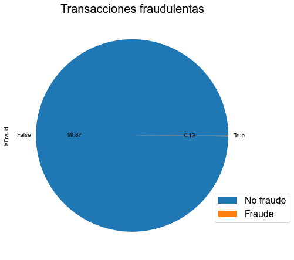

```python
fig, ax = plt.subplots(figsize=(7, 7))
XY['isFraud'].value_counts().plot(kind='pie', autopct='%.2f', labeldistance=1.05, ax=ax)

# Añadir etiquetas
ax.legend(labels=['No fraude', 'Fraude'], loc='center', bbox_to_anchor=(1, 0.2),fontsize=16)
plt.tight_layout()

# Ajustar tamaño de la fuente y añadir sombra
plt.rcParams['font.size'] = 16
plt.rcParams['axes.titlepad'] = 16

# Añadir fondo
plt.style.use('seaborn')

# Añadir título y reducir espacio con el gráfico
plt.title('Transacciones fraudulentas', fontsize=20, pad=0.5)

plt.savefig('figure.tiff', dpi=300, format='tiff')
plt.show()
```

Podemos observar una gran desigualdad de los datos, lo que a la hora de predecir puede presentar un error y sobreestimar los resultados, ya que más del 99% son transacciones no fraudulentas. Por ello, vamos a reorganizar el dataframe, buscando un resultado menos sesgado.

```python
XY.isna().sum() #Chequeamos si hay valores nulos
```

```
step              0
type              0
amount            0
nameOrig          0
oldbalanceOrg     0
newbalanceOrig    0
nameDest          0
oldbalanceDest    0
newbalanceDest    0
isFraud           0
isFlaggedFraud    0
dtype: int64
```

#### Analizamos el comportamiento de cada variable

```python
#XY['step'].unique()#activar solo si se quieren ver los valores únicos. En este caso solo nos interesa saber el nº de instantes de tiempo diferentes
XY['step'].value_counts()
```

```
19     51352
18     49579
187    49083
235    47491
307    46968
       ...
432        4
706        4
693        4
112        2
662        2
Name: step, Length: 743, dtype: int64
```

```python
CUANTAS_TIPO_TRANS =XY['type'].value_counts()
print(CUANTAS_TIPO_TRANS)
```

```
CASH_OUT    2237500
PAYMENT     2151495
CASH_IN     1399284
TRANSFER     532909
DEBIT         41432
Name: type, dtype: int64
```

Hay 743 instantes diferentes.

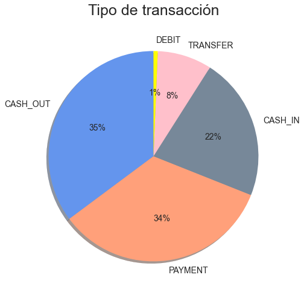

```python
plt.figure(figsize=(8,8))

plt.pie(XY.type.value_counts().values,labels=XY.type.value_counts().index, autopct='%.0f%%',shadow=True,
        startangle=90,colors = ('#6495ED', '#FFA07A', '#778899', '#FFC0CB', 'yellow', '#008080' ), textprops={'fontsize': 14})
plt.title("Tipo de transacción",fontsize=25)
plt.savefig('tipo_transac.tiff', dpi=300, format='tiff')
plt.savefig('figure.tiff', dpi=300, format='tiff')
plt.show()
```

Se puede ver que hay una diferencia considerable entre los tipos de acciones, yaroitariamente se dan transacciones tipo cash-out y payment, seguids de chas_in y transfer. Las transaciones de débito unicamente constituyen 1%

Hay 5 tipos de transacciones. ¿cuales se usan para cometer fraude?

```python
print (XY.type.value_counts())

print('Tipo de transacción donde se da fraude:')
list(XY.loc[XY.isFraud == 1].type.drop_duplicates().values) #tipo de transac. que si hay fraude
```

```
CASH_OUT    2237500
PAYMENT     2151495
CASH_IN     1399284
TRANSFER     532909
DEBIT         41432
Name: type, dtype: int64
Tipo de transacción donde se da fraude:
```

```
['TRANSFER', 'CASH_OUT']
```

```python
XY['hora']=XY['step']%24
XY['dia']=XY['step']%31
```

```python
XY['hora'].unique()
```

```
array([ 1,  2,  3,  4,  5,  6,  7,  8,  9, 10, 11, 12, 13, 14, 15, 16, 17,
       18, 19, 20, 21, 22, 23,  0], dtype=int64)
```

```python
XY.head(5)
```

|  | step | type | amount | nameOrig | oldbalanceOrg | newbalanceOrig | nameDest | oldbalanceDest | newbalanceDest | isFraud | isFlaggedFraud | hora | dia |
| --- | --- | --- | --- | --- | --- | --- | --- | --- | --- | --- | --- | --- | --- |
| 0 | 1 | PAYMENT | 9839.64 | C1231006815 | 170136.0 | 160296.36 | M1979787155 | 0.0 | 0.0 | False | False | 1 | 1 |
| 1 | 1 | PAYMENT | 1864.28 | C1666544295 | 21249.0 | 19384.72 | M2044282225 | 0.0 | 0.0 | False | False | 1 | 1 |
| 2 | 1 | TRANSFER | 181.00 | C1305486145 | 181.0 | 0.00 | C553264065 | 0.0 | 0.0 | True | False | 1 | 1 |
| 3 | 1 | CASH_OUT | 181.00 | C840083671 | 181.0 | 0.00 | C38997010 | 21182.0 | 0.0 | True | False | 1 | 1 |
| 4 | 1 | PAYMENT | 11668.14 | C2048537720 | 41554.0 | 29885.86 | M1230701703 | 0.0 | 0.0 | False | False | 1 | 1 |

```python
# Agrupa los datos por hora y dia cuenta el número total de transacciones
Total_hora = XY.groupby('hora').size().reset_index(name='count')
Total_dia = XY.groupby('dia').size().reset_index(name='count')
# Calcula la frecuencia porcentual
Total_hora['frequency'] = Total_hora['count'] / Total_hora['count'].sum() * 100
Total_dia['frequency'] = Total_dia['count'] / Total_dia['count'].sum() * 100
```

```python
Total_hora.head(10)
```

|  | hora | count | frequency |
| --- | --- | --- | --- |
| 0 | 0 | 71587 | 1.125118 |
| 1 | 1 | 27111 | 0.426098 |
| 2 | 2 | 9018 | 0.141734 |
| 3 | 3 | 2007 | 0.031544 |
| 4 | 4 | 1241 | 0.019505 |
| 5 | 5 | 1641 | 0.025791 |
| 6 | 6 | 3420 | 0.053751 |
| 7 | 7 | 8988 | 0.141263 |
| 8 | 8 | 26915 | 0.423018 |
| 9 | 9 | 283518 | 4.455995 |

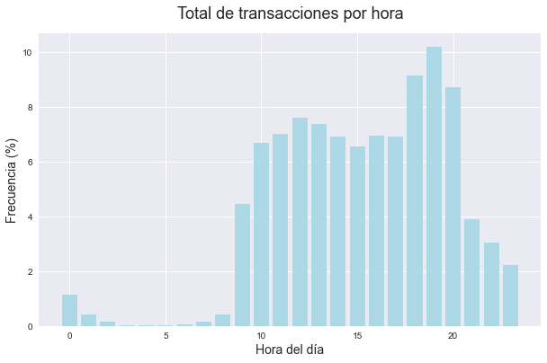

```python
#  pintamos histograma
plt.figure(figsize=(10, 6))
plt.bar(Total_hora['hora'], Total_hora['frequency'],color='lightblue')
plt.title('Total de transacciones por hora',fontsize=18)
plt.xlabel('Hora del día',fontsize=14)
plt.ylabel('Frecuencia (%)',fontsize=14)

plt.savefig('figure_tipo_trans_hora.tiff', dpi=300, format='tiff')
```

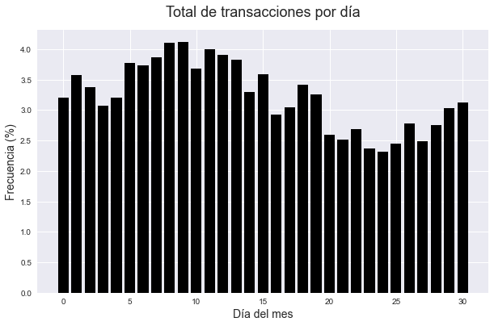

```python
#  pintamos histograma
plt.figure(figsize=(10, 6))
plt.bar(Total_dia['dia'], Total_dia['frequency'],color='black')
plt.title('Total de transacciones por día',fontsize=18)
plt.xlabel('Día del mes',fontsize=14)
plt.ylabel('Frecuencia (%)',fontsize=14)
# Guarda el gráfico como un  PNG
#plt.savefig('histograma_todas_transacciones_por_dia.png')
```

```python
XY_grouped_HORA = XY.groupby(['hora', 'type']).size().reset_index(name='count')
```

```python
XY_grouped_HORA['frequency'] = XY_grouped_HORA.groupby('hora')['count'].apply(lambda x: x / x.sum() * 100)
```

```python
pivot_table = XY_grouped_HORA.pivot(index='hora', columns='type', values='frequency')
```

```python
pivot_table.head(10)
```

| type hora | CASH_IN | CASH_OUT | DEBIT | PAYMENT | TRANSFER |
| --- | --- | --- | --- | --- | --- |
| 0 | 15.603392 | 16.758629 | 2.300697 | 56.652744 | 8.684538 |
| 1 | 17.907860 | 14.377928 | 4.190181 | 55.752278 | 7.771753 |
| 2 | 26.114438 | 13.927700 | 4.978931 | 47.593701 | 7.385230 |
| 3 | 20.777280 | 21.524664 | 2.889885 | 37.468859 | 17.339312 |
| 4 | 18.533441 | 22.320709 | 2.095085 | 38.114424 | 18.936342 |
| 5 | 18.403413 | 22.730043 | 1.767215 | 41.316271 | 15.783059 |
| 6 | 17.807018 | 15.116959 | 1.491228 | 54.269006 | 11.315789 |
| 7 | 15.609702 | 16.622163 | 1.535381 | 54.572764 | 11.659991 |
| 8 | 19.082296 | 28.456251 | 0.702211 | 41.939439 | 9.819803 |
| 9 | 22.692386 | 33.445848 | 0.552346 | 34.420037 | 8.889383 |

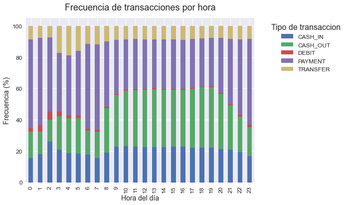

```python
# Crear el gráfico de barras apiladas con la tabla pivote
ax = pivot_table.plot.bar(stacked=True, figsize=(10, 6))

# Personalizar los ejes y la leyenda
ax.set_title('Frecuencia de transacciones por hora', fontsize=18)
ax.set_xlabel('Hora del día', fontsize=14)
ax.set_ylabel('Frecuencia (%)', fontsize=14)
ax.legend(title='Tipo de transaccion', bbox_to_anchor=(1.05, 1), loc='upper left', fontsize=12)

# Ajustar el tamaño de las etiquetas y la leyenda
plt.xticks(fontsize=12)
plt.yticks(fontsize=12)
plt.tight_layout()

# Mostrar el gráfico
plt.savefig('figure_tipo_trans_hora_tipo.tiff', dpi=300, format='tiff')
plt.show()
```

```python
hora_tipo = XY.groupby(['type', 'hora']).size().reset_index(name='count') # agrupamos por tipo de transac y por hora
pivot_table = pd.pivot_table(hora_tipo, values='count', index='hora', columns='type') #transformamos los datos para pintarlos
```

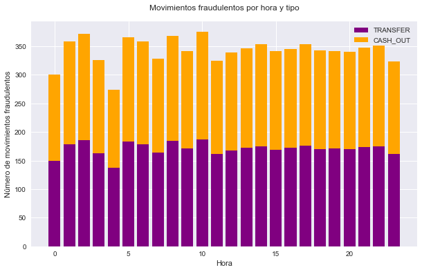

```python
# Obtener los movimientos fraudulentos por hora y tipo
fraudulent_by_hour_type = XY.loc[XY.isFraud==1].groupby(['hora','type']).size().unstack()

# Crear el gráfico
fig, ax = plt.subplots(figsize=(10,6))

# Pintar los movimientos fraudulentos de tipo TRANSFER
ax.bar(fraudulent_by_hour_type.index, fraudulent_by_hour_type['TRANSFER'], color='purple', label='TRANSFER')

# Pintar los movimientos fraudulentos de tipo CASH_OUT
ax.bar(fraudulent_by_hour_type.index, fraudulent_by_hour_type['CASH_OUT'], color='orange', label='CASH_OUT', bottom=fraudulent_by_hour_type['TRANSFER'])

# Configurar el gráfico
ax.set_xlabel('Hora')
ax.set_ylabel('Número de movimientos fraudulentos')
ax.set_title('Movimientos fraudulentos por hora y tipo')
ax.legend()
plt.savefig('fraude_por_horas.tiff', dpi=300, format='tiff')
plt.show()
```

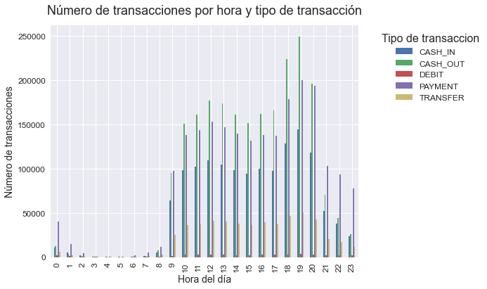

```python
ax = pivot_table.plot(kind='bar', figsize=(10, 6))
ax.set_title('Número de transacciones por hora y tipo de transacción', fontsize=18)
ax.set_xlabel('Hora del día', fontsize=14)
ax.set_ylabel('Número de transacciones', fontsize=14)
ax.legend(title='Tipo de transaccion', bbox_to_anchor=(1.05, 1), loc='upper left', fontsize=12)

# Ajustar el tamaño de las etiquetas y la leyenda
plt.xticks(fontsize=12)
plt.yticks(fontsize=12)
plt.tight_layout()

# Mostrar el histograma
plt.show()
```

Una vez visto como se comporta cada tipo de transacción por hora, y sabiendo que sólo se cometen acciones fraudulentas en Transfer y cash-out. Vamos a explorar esos dos un poco más en detalle, en relación a las variables origen y destino. Para ello vamos a analizar si cada origen y destino es único o se producen varias transacciones fraudulentas de un mismo origen a un mismo destino o de origenes diferentes a mismo destino o viceversa. Para eso vamos a ver cómo de unicos son cada una de las variables

```python
#lo primero es ver cuantas del total de transacciones fraudulentas corresponden a cada typo
transfer=XY.loc[(XY.isFraud==1) & (XY.type=='TRANSFER')]
cash_out=XY.loc[(XY.isFraud==1) & (XY.type=='CASH_OUT')]
print('Fraudulent Transfers',len(transfer))
print('Fraudulent Cash Outs',len(cash_out))
```

```
Fraudulent Transfers 4097
Fraudulent Cash Outs 4116
```

```python
# de todas las transacciones cuales corresponden a mas de 200.000 y que typo de trnasaccion es
num_fraud_trans = len(XY[XY['isFlaggedFraud'] == 1]) #numero de transac donde isflaggedfraud=1
fraud_trans_type = XY.loc[XY['isFlaggedFraud'] == 1, 'type'].unique()[0]
print("Número de transacciones marcadas como fraude: ", num_fraud_trans)
print("Tipo de transacción de las transacciones marcadas como fraude: ", fraud_trans_type)
```

```
Número de transacciones marcadas como fraude:  16
Tipo de transacción de las transacciones marcadas como fraude:  TRANSFER
```

vamos a ver como se comporta la variable amount

1. primero vemos cual es el máximo, el mínimo de cada tipo de transaccion.

```python
max_amount = XY.groupby('type')['amount'].max() #max por tipo de transac
min_amount = XY.groupby('type')['amount'].min() #min por tipo de transac
mean_amount = XY.groupby('type')['amount'].mean() #promedio por tipo de transac
print("Máximo de amount por tipo de transacción:\n", max_amount)
print("\nMínimo de amount por tipo de transacción:\n", min_amount)
print("\nPromedio de amount por tipo de transacción:\n", mean_amount)
```

```
Máximo de amount por tipo de transacción:
 type
CASH_IN      1915267.90
CASH_OUT    10000000.00
DEBIT         569077.51
PAYMENT       238637.98
TRANSFER    92445516.64
Name: amount, dtype: float64

Mínimo de amount por tipo de transacción:
 type
CASH_IN     0.04
CASH_OUT    0.00
DEBIT       0.55
PAYMENT     0.02
TRANSFER    2.60
Name: amount, dtype: float64

Promedio de amount por tipo de transacción:
 type
CASH_IN     168920.242004
CASH_OUT    176273.964346
DEBIT         5483.665314
PAYMENT      13057.604660
TRANSFER    910647.009645
Name: amount, dtype: float64
```

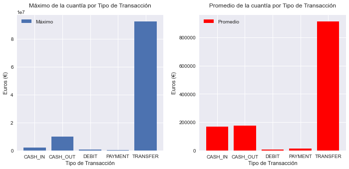

```python
fig, axs = plt.subplots(1, 2, figsize=(10, 5))

# Gráfica del máximo
axs[0].bar(max_amount.index, max_amount.values, label='Máximo', bottom=None)
axs[0].set_xlabel('Tipo de Transacción')
axs[0].set_ylabel('Euros (€)')
axs[0].set_title('Máximo de la cuantía por Tipo de Transacción')
axs[0].legend()

# Gráfica del promedio
axs[1].bar(mean_amount.index, mean_amount.values,color='red', label='Promedio',bottom=None)
axs[1].set_xlabel('Tipo de Transacción')
axs[1].set_ylabel('Euros (€)')
axs[1].set_title('Promedio de la cuantía por Tipo de Transacción')
axs[1].legend()

# Ajustar la disposición de los subplots
plt.tight_layout()

plt.savefig('figure_maximo_mean_amount_subplot.tiff', dpi=300, format='tiff')
# Mostrar el gráfico
plt.show()
```

1. Ahora vemos como varian en función del tiempo las cuantías medias de cada tipo

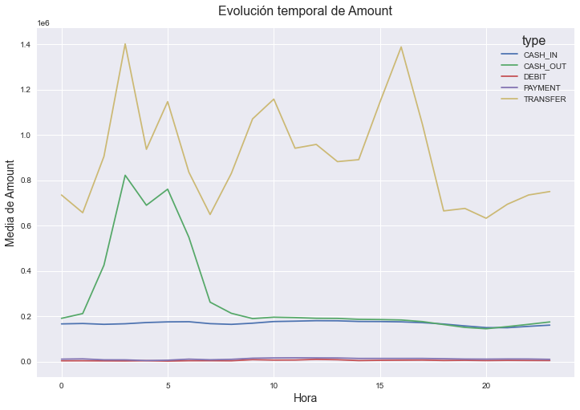

```python
hourly_mean = XY.pivot_table(index='type', columns='hora', values='amount', aggfunc='mean')
#print(hourly_mean_2) #visualizar en pantalla el resultado
#pintamos variacion temporal
fig, ax = plt.subplots(figsize=(12,8))
hourly_mean.T.plot(ax=ax, legend=True)
ax.set_xlabel('Hora',fontsize=14)
ax.set_ylabel('Media de Amount',fontsize=14)
ax.set_title('Evolución temporal de Amount',fontsize=16)
plt.savefig('figure_amuon_tiome_portipo.tiff', dpi=300, format='tiff')
plt.show()
```

Este gráfico muestra cómo varía la media de 'amount' para cada tipo de transacción a lo largo del día en el conjunto de datos Paysym. Podemos ver claramente cómo cambia la media de 'amount' para cada tipo de transacción a lo largo del día, y podemos comparar fácilmente la evolución de cada tipo de transacción entre sí.

```python
hourly_mean.head(5)
```

| hora type | 0 | 1 | 2 | 3 | 4 | 5 | 6 | 7 | 8 | 9 | ... | 14 | 15 | 16 | 17 | 18 | 19 | 20 | 21 | 22 | 23 |
| --- | --- | --- | --- | --- | --- | --- | --- | --- | --- | --- | --- | --- | --- | --- | --- | --- | --- | --- | --- | --- | --- |
| CASH_IN | 165902.008372 | 167649.579633 | 163996.395062 | 1.664809e+05 | 171882.874043 | 1.748080e+05 | 175509.409688 | 166979.843108 | 163862.295880 | 1.690264e+05 | ... | 176627.090008 | 1.762852e+05 | 1.749270e+05 | 1.713935e+05 | 165327.115516 | 157013.005005 | 149548.226793 | 149030.729896 | 155109.155383 | 160510.031639 |
| CASH_OUT | 190416.525511 | 211468.281044 | 424843.090748 | 8.218980e+05 | 689476.071264 | 7.604321e+05 | 548322.396480 | 261860.500475 | 212708.093605 | 1.893202e+05 | ... | 186101.383110 | 1.851000e+05 | 1.832259e+05 | 1.761007e+05 | 163165.903506 | 150503.477231 | 144483.203316 | 153955.834180 | 163976.403402 | 174524.203179 |
| DEBIT | 3101.942508 | 3222.854877 | 2758.751091 | 2.485301e+03 | 3315.090385 | 1.793410e+03 | 3528.147451 | 3498.235362 | 3137.482540 | 8.083000e+03 | ... | 3991.597955 | 5.189242e+03 | 5.782562e+03 | 6.248208e+03 | 4383.665157 | 5227.805394 | 4087.648109 | 4872.646366 | 4493.950877 | 4214.948341 |
| PAYMENT | 10401.466060 | 11580.304343 | 7324.780767 | 7.196014e+03 | 4238.905666 | 5.696066e+03 | 10372.830156 | 7539.927780 | 9469.984769 | 1.444168e+04 | ... | 13480.721052 | 1.352598e+04 | 1.352416e+04 | 1.358610e+04 | 12264.964928 | 10751.510065 | 10432.150749 | 11089.844731 | 10955.482599 | 9549.673966 |
| TRANSFER | 734860.475482 | 656602.563678 | 904872.958994 | 1.401637e+06 | 936431.091234 | 1.146750e+06 | 835506.355426 | 648567.248454 | 829948.359398 | 1.070563e+06 | ... | 890647.635662 | 1.144526e+06 | 1.388039e+06 | 1.046798e+06 | 664497.175882 | 675485.022139 | 632156.686442 | 693864.979865 | 734801.257216 | 749980.126581 |

5 rows × 24 columns

```python
#ver si hay valores negativos en amount
print("Transacciones amount negativas : " + str(sum(XY['amount'] < 0)))

#amount= 0
print("Transacciones amount=0: " + str(sum(XY['amount'] == 0)))
```

```
Transacciones amount negativas : 0
Transacciones amount=0: 16
```

```python
AMOUNT_0 = XY[XY['amount'] == 0]
AMOUNT_0
```

|  | step | type | amount | nameOrig | oldbalanceOrg | newbalanceOrig | nameDest | oldbalanceDest | newbalanceDest | isFraud | isFlaggedFraud | hora | dia |
| --- | --- | --- | --- | --- | --- | --- | --- | --- | --- | --- | --- | --- | --- |
| 2736447 | 212 | CASH_OUT | 0.0 | C1510987794 | 0.0 | 0.0 | C1696624817 | 0.00 | 0.00 | True | False | 20 | 26 |
| 3247298 | 250 | CASH_OUT | 0.0 | C521393327 | 0.0 | 0.0 | C480398193 | 0.00 | 0.00 | True | False | 10 | 2 |
| 3760289 | 279 | CASH_OUT | 0.0 | C539112012 | 0.0 | 0.0 | C1106468520 | 538547.63 | 538547.63 | True | False | 15 | 0 |
| 5563714 | 387 | CASH_OUT | 0.0 | C1294472700 | 0.0 | 0.0 | C1325541393 | 7970766.57 | 7970766.57 | True | False | 3 | 15 |
| 5996408 | 425 | CASH_OUT | 0.0 | C832555372 | 0.0 | 0.0 | C1462759334 | 76759.90 | 76759.90 | True | False | 17 | 22 |
| 5996410 | 425 | CASH_OUT | 0.0 | C69493310 | 0.0 | 0.0 | C719711728 | 2921531.34 | 2921531.34 | True | False | 17 | 22 |
| 6168500 | 554 | CASH_OUT | 0.0 | C10965156 | 0.0 | 0.0 | C1493336195 | 230289.66 | 230289.66 | True | False | 2 | 27 |
| 6205440 | 586 | CASH_OUT | 0.0 | C1303719003 | 0.0 | 0.0 | C900608348 | 1328472.86 | 1328472.86 | True | False | 10 | 28 |
| 6266414 | 617 | CASH_OUT | 0.0 | C1971175979 | 0.0 | 0.0 | C1352345416 | 0.00 | 0.00 | True | False | 17 | 28 |
| 6281483 | 646 | CASH_OUT | 0.0 | C2060908932 | 0.0 | 0.0 | C1587892888 | 0.00 | 0.00 | True | False | 22 | 26 |
| 6281485 | 646 | CASH_OUT | 0.0 | C1997645312 | 0.0 | 0.0 | C601248796 | 0.00 | 0.00 | True | False | 22 | 26 |
| 6296015 | 671 | CASH_OUT | 0.0 | C1960007029 | 0.0 | 0.0 | C459118517 | 27938.72 | 27938.72 | True | False | 23 | 20 |
| 6351226 | 702 | CASH_OUT | 0.0 | C1461113533 | 0.0 | 0.0 | C1382150537 | 107777.02 | 107777.02 | True | False | 6 | 20 |
| 6362461 | 730 | CASH_OUT | 0.0 | C729003789 | 0.0 | 0.0 | C1388096959 | 1008609.53 | 1008609.53 | True | False | 10 | 17 |
| 6362463 | 730 | CASH_OUT | 0.0 | C2088151490 | 0.0 | 0.0 | C1156763710 | 0.00 | 0.00 | True | False | 10 | 17 |
| 6362585 | 741 | CASH_OUT | 0.0 | C312737633 | 0.0 | 0.0 | C1400061387 | 267522.87 | 267522.87 | True | False | 21 | 28 |

Una vez conocidos el numero de transac fraudulentas y el numero de ellas que son marcadas como fraude, se procede a analizar la cuantia que se mueve en cada caso, si son fraude o no son fraude de los dos tipos que comenten estas actividades

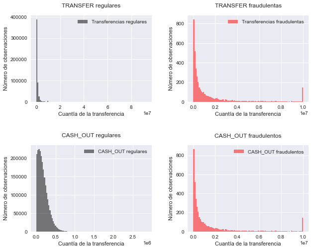

```python
plot_transfer_histograms(XY,
                         #title="Histogramas de transferencias regulares y fraudulentas",
                         xlabel="Cuantía de la transferencia",
                         ylabel="Número de observaciones",
                         alpha=0.5,
                        bins=100,
                         )
```

```python
max_transfer_fraud_TRANSFER =XY[(XY["type"] == "TRANSFER") & (XY["isFraud"] == 1)]["amount"].max()
print(max_transfer_fraud_TRANSFER)
max_transfer_fraud_CASH_OUT = XY[(XY["type"] == "CASH_OUT") & (XY["isFraud"] == 1)]["amount"].max()
print(max_transfer_fraud_CASH_OUT)
min_transfer_fraud_TRANSFER =XY[(XY["type"] == "TRANSFER") & (XY["isFraud"] == 1)]["amount"].min()
print(min_transfer_fraud_TRANSFER)
min_transfer_fraud_CASH_OUT = XY[(XY["type"] == "CASH_OUT") & (XY["isFraud"] == 1)]["amount"].min()
print(min_transfer_fraud_CASH_OUT)
mean_transfer_fraud_TRANSFER =XY[(XY["type"] == "TRANSFER") & (XY["isFraud"] == 1)]["amount"].mean()
print(mean_transfer_fraud_TRANSFER)
mean_transfer_fraud_CASH_OUT = XY[(XY["type"] == "CASH_OUT") & (XY["isFraud"] == 1)]["amount"].mean()
print(mean_transfer_fraud_CASH_OUT)
```

```
10000000.0
10000000.0
63.8
0.0
1480891.6729338474
1455102.5859645216
```

Analizamos las variables NameOrg, NameDest, y los balances.

1. ver si son únicos

```python
XYFraud = XY.loc[XY.isFraud == 1]
XYNonFraud = XY.loc[XY.isFraud == 0]
```

```python
print("\nNúmero de origenes diferentes (NAMEORG) en transacciones fraudulentas que sean tipo TRANSFER: {} / {}".format(len(XYFraud.loc[XYFraud.type == 'TRANSFER'].nameOrig.drop_duplicates().values),len(XYFraud.loc[XYFraud.type == 'TRANSFER'])))
print("Número de destinatarios diferentes(NAMEDEST) en transacciones fraudulentas que sean tipo TRANSFER: {} / {}".format(len(XYFraud.loc[XYFraud.type == 'TRANSFER'].nameDest.drop_duplicates().values),len(XYFraud.loc[XYFraud.type == 'TRANSFER'])))
print("\nNúmero de origenes  (NAMEORG) diferentes en transacciones fraudulentas que sean tipo CASH-OUT: {} / {}".format(len(XYFraud.loc[XYFraud.type == 'CASH_OUT'].nameOrig.drop_duplicates().values),len(XYFraud.loc[XYFraud.type == 'CASH_OUT'])))
print("\nNúmero de destinatarios  (NAMEDEST) diferentes en transacciones fraudulentas que sean tipo CASH-OUT: {} / {}".format(len(XYFraud.loc[XYFraud.type == 'CASH_OUT'].nameDest.drop_duplicates().values),len(XYFraud.loc[XYFraud.type == 'CASH_OUT'])))
```

```
Número de origenes diferentes (NAMEORG) en transacciones fraudulentas que sean tipo TRANSFER: 4097 / 4097
Número de destinatarios diferentes(NAMEDEST) en transacciones fraudulentas que sean tipo TRANSFER: 4097 / 4097

Número de origenes  (NAMEORG) diferentes en transacciones fraudulentas que sean tipo CASH-OUT: 4116 / 4116

Número de destinatarios  (NAMEDEST) diferentes en transacciones fraudulentas que sean tipo CASH-OUT: 4091 / 4116
```

```python
# Filtrar las transacciones de tipo "CASH_OUT"
cash_out = XYFraud[XYFraud['type'] == 'CASH_OUT']

# Encontrar los valores que se repiten en la columna "name_dest"
repeated_names = cash_out['nameDest'].value_counts()[cash_out['nameDest'].value_counts() > 1]

# Imprimir los valores repetidos
print(repeated_names)
```

```
C1650668671    2
C1325541393    2
C967226405     2
C200064275     2
C1655359478    2
C1981613973    2
C475338087     2
C1193568854    2
C1013511446    2
C1460854172    2
C803116137     2
C686334805     2
C643624257     2
C644163395     2
C964377943     2
C2020337583    2
C1497532505    2
C505532836     2
C1980653895    2
C105660024     2
C1601170327    2
C185805228     2
C1399829166    2
C2129197098    2
C385133759     2
Name: nameDest, dtype: int64
```

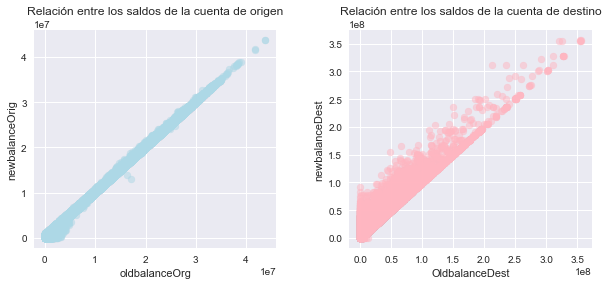

```python
# Crear la figura y los subplots
fig, axs = plt.subplots(1, 2, figsize=(10, 4))

# Diagrama de dispersión 1: oldbalanceOrig vs newbalanceOrig
axs[0].scatter(XYNonFraud['oldbalanceOrg'], XYNonFraud['newbalanceOrig'], alpha=0.5, color='lightblue')
axs[0].set_xlabel('oldbalanceOrg')
axs[0].set_ylabel('newbalanceOrig')
axs[0].set_title('Relación entre los saldos de la cuenta de origen')

# Diagrama de dispersión 2: oldbalancedest vs newbalancedest
axs[1].scatter(XYNonFraud['oldbalanceDest'], XYNonFraud['newbalanceDest'], alpha=0.5, color='lightpink')
axs[1].set_xlabel('OldbalanceDest')
axs[1].set_ylabel('newbalanceDest')
axs[1].set_title('Relación entre los saldos de la cuenta de destino')

# Ajustar el espacio entre los subplots
plt.subplots_adjust(wspace=0.3)
plt.savefig('relacion_saldo_nofraude.tiff', dpi=300, format='tiff')
# Mostrar el subplot
plt.show()
```

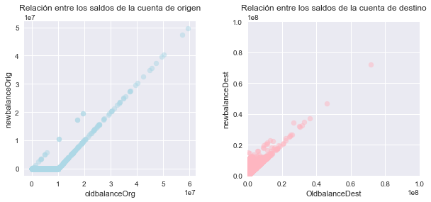

```python
# Crear la figura y los subplots
fig, axs = plt.subplots(1, 2, figsize=(10, 4))

# Diagrama de dispersión 1: oldbalanceOrig vs newbalanceOrig
axs[0].scatter(XYFraud['oldbalanceOrg'], XYFraud['newbalanceOrig'], alpha=0.5, color='lightblue')
axs[0].set_xlabel('oldbalanceOrg')
axs[0].set_ylabel('newbalanceOrig')
axs[0].set_title('Relación entre los saldos de la cuenta de origen')

# Diagrama de dispersión 2: oldbalancedest vs newbalancedest
axs[1].scatter(XYFraud['oldbalanceDest'], XYFraud['newbalanceDest'], alpha=0.5, color='lightpink')
axs[1].set_xlabel('OldbalanceDest')
axs[1].set_ylabel('newbalanceDest')
axs[1].set_title('Relación entre los saldos de la cuenta de destino')
axs[1].set_xlim([0, 1e8])
axs[1].set_ylim([0, 1e8])
# Ajustar el espacio entre los subplots
plt.subplots_adjust(wspace=0.3)
plt.savefig('relacion_saldo_fraude.tiff', dpi=300, format='tiff')
# Mostrar el subplot
plt.show()
```

```python
name_orig_letters = XY['nameOrig'].str[0].value_counts(normalize=True)
print(name_orig_letters)
name_DEST_letters = XY['nameDest'].str[0].value_counts(normalize=True)
print(name_DEST_letters)
```

```
C    1.0
Name: nameOrig, dtype: float64
C    0.661854
M    0.338146
Name: nameDest, dtype: float64
```

PODEMOS VER LOS TIPOS DE CLIENTES QUE HAY, EN LAS CUENTAS ORIGEN, TODOS LOS CLIENTES SON CLIENTES (CUSTOMERS) PERO SIN EMBARGO, EN LOS DESTINATARIOS PODEMOS VER QUE HAY TANTO CLIENTES COMO COMERCIANTES. VAMOS A VER LA PORPORCIÓN DE ESTOS A LO LARGO DE TODO EL CONJUNTO Y VER SI HAY ALGÚN PATRON CON LAS TRANSAC FRAUDULENTAS

```python
 XY_2= XY.copy()
XY_2["Type2"] = np.nan

XY_2.loc[XY.nameOrig.str.contains('C') & XY.nameDest.str.contains('C'),"Type2"] = "CC"
XY_2.loc[XY.nameOrig.str.contains('C') & XY.nameDest.str.contains('M'),"Type2"] = "CM"
```

```python
# Contar la frecuencia de cada valor en la columna "Type2"
counts = XY_2["Type2"].value_counts()

# Calcular el porcentaje de veces que es "CC" y "CM"
porcentaje_CC = counts["CC"] / XY_2.shape[0] * 100
porcentaje_CM = counts["CM"] / XY_2.shape[0] * 100

# Imprimir los resultados
print(f"Porcentaje de veces que es CC: {porcentaje_CC:.2f}%")
print(f"Porcentaje de veces que es CM: {porcentaje_CM:.2f}%")
```

```
Porcentaje de veces que es CC: 66.19%
Porcentaje de veces que es CM: 33.81%
```

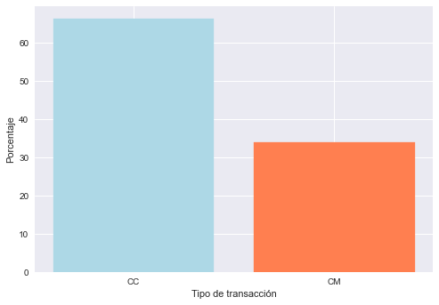

```python
# Crear una lista de los porcentajes
porcentajes = [porcentaje_CC, porcentaje_CM]

# Crear una lista de los nombres de las barras
nombres_barras = ["CC", "CM"]

# Crear el gráfico de barras
bars=plt.bar(nombres_barras, porcentajes)
bars[0].set_color("lightblue")
bars[1].set_color("coral")


# Añadir títulos y etiquetas de los ejes
#plt.title("Porcentaje de transacciones CC y CM")
plt.xlabel("Tipo de transacción")
plt.ylabel("Porcentaje")
plt.savefig('relacion_cc_cm.tiff', dpi=300, format='tiff')
# Mostrar el gráfico
plt.show()
```

```python
# Seleccionar solo las transacciones con isFraud=1
isFraud_1 = XY_2.loc[XY_2["isFraud"] == 1]

# Contar la frecuencia de cada valor en la columna "Type2" de las transacciones con isFraud=1
counts = isFraud_1["Type2"].value_counts()
print(counts)
```

```
CC    8213
Name: Type2, dtype: int64
```

```python
# Seleccionar filas que no empiezan por "C" ni por "M"
not_CM = ~XY_2["nameOrig"].str.startswith(("C", "M"))

# Verificar si hay alguna fila seleccionada
if not_CM.any():
    print("Hay filas que no empiezan por 'C' ni por 'M' en la columna 'nameOrig'")
else:
    print("Todas las filas de la columna 'nameOrig' empiezan por 'C' o 'M'")
```

```
Todas las filas de la columna 'nameOrig' empiezan por 'C' o 'M'
```

```python
# Obtener los valores únicos de la columna isFraud
fraud_values = XY_2["isFraud"].unique()

# Filtrar el dataframe original XY_2 con los valores únicos de isFraud
filtered_XY_2 = XY_2[XY_2["isFraud"].isin(fraud_values)]

# Verificar si hay valores diferentes a 1 o 0 en la columna isFraud
if len(filtered_XY_2["isFraud"].unique()) > 2:
    print("Hay valores diferentes a 1 o 0 en la columna isFraud")
else:
    print("No hay valores diferentes a 1 o 0 en la columna isFraud")
```

```
No hay valores diferentes a 1 o 0 en la columna isFraud
```

creamos un conjuntodónde se recojan las transacciones donde amoun > 0. VAMOS A VER SI CUADRA EL BALANCE ES DECIR:

1. origen: Old-Amount=new balance
2. destino: old+amount= new

```python
# Crear filtro para seleccionar transacciones que cumplen con ambas condiciones
filtro1 = (XY_2["oldbalanceOrg"] - XY_2["amount"] == XY_2["newbalanceOrig"]) & (XY_2["oldbalanceDest"] + XY_2["amount"] == XY_2["newbalanceDest"])
filtro2 = (XY_2["oldbalanceOrg"] - XY_2["amount"] == XY_2["newbalanceOrig"])
filtro3 = (XY_2["oldbalanceDest"] + XY_2["amount"] == XY_2["newbalanceDest"])

# Contar el número de transacciones que cumplen con ambas condiciones
num_transacciones_a = len(XY_2[filtro1])
num_transacciones_b = len(XY_2[filtro2])
num_transacciones_c = len(XY_2[filtro3])
print(f"El número de transacciones que cumplen con ambas condiciones es: {num_transacciones_a}")
print(f"El número de transacciones que cumplen EN ORIGEN: {num_transacciones_b}")
print(f"El número de transacciones que cumplen EN DESTINO: {num_transacciones_c}")
```

```
El número de transacciones que cumplen con ambas condiciones es: 122057
El número de transacciones que cumplen EN ORIGEN: 948623
El número de transacciones que cumplen EN DESTINO: 1625946
```

```python
# Crear filtro para seleccionar transacciones que cumplen con ambas condiciones y que tengan isfraud = 1
filtro1_1 = (XY_2["oldbalanceOrg"] - XY_2["amount"] == XY_2["newbalanceOrig"]) & (XY_2["oldbalanceDest"] + XY_2["amount"] == XY_2["newbalanceDest"]) & (XY_2["isFraud"] == 1)
filtro2_2= (XY_2["oldbalanceOrg"] - XY_2["amount"] == XY_2["newbalanceOrig"]) & (XY_2["isFraud"] == 1)
filtro3_3 = (XY_2["oldbalanceDest"] + XY_2["amount"] == XY_2["newbalanceDest"]) & (XY_2["isFraud"] == 1)

# Contar el número de transacciones que cumplen con ambas condiciones y que tengan isfraud = 1
num_transacciones_aa = len(XY_2[filtro1_1])
num_transacciones_bb = len(XY_2[filtro2_2])
num_transacciones_cc = len(XY_2[filtro3_3])
print(f"El número de transacciones que cumplen con ambas condiciones y tienen isFraud = 1 es: {num_transacciones_aa}")
print(f"El número de transacciones que cumplen EN ORIGEN y tienen isFraud = 1 es: {num_transacciones_bb}")
print(f"El número de transacciones que cumplen EN DESTINO y tienen isFraud = 1 es: {num_transacciones_cc}")
```

```
El número de transacciones que cumplen con ambas condiciones y tienen isFraud = 1 es: 2874
El número de transacciones que cumplen EN ORIGEN y tienen isFraud = 1 es: 8086
El número de transacciones que cumplen EN DESTINO y tienen isFraud = 1 es: 2889
```

```python
num_orig = len(XY_2["oldbalanceOrg"])
print(f"El número de transacciones que cumplen con ambas condiciones es: {num_orig}")
```

```
El número de transacciones que cumplen con ambas condiciones es: 6362620
```

```python
type_transacciones_a = XY_2.loc[filtro1, "type"]
print(type_transacciones_a.value_counts())
type_transacciones_b = XY_2.loc[filtro2, "type"]
print(type_transacciones_b.value_counts())
type_transacciones_c = XY_2.loc[filtro3, "type"]
print(type_transacciones_c.value_counts())
```

```
CASH_OUT    101198
DEBIT        13518
TRANSFER      7341
CASH_IN          0
PAYMENT          0
Name: type, dtype: int64
PAYMENT     748976
CASH_OUT    158404
DEBIT        25551
TRANSFER     15692
CASH_IN          0
Name: type, dtype: int64
CASH_OUT    1303685
TRANSFER     300540
DEBIT         21721
CASH_IN           0
PAYMENT           0
Name: type, dtype: int64
```

```python
type_transacciones_aa = XY_2.loc[filtro1_1, "type"]
print(type_transacciones_aa.value_counts())
type_transacciones_bb = XY_2.loc[filtro2_2, "type"]
print(type_transacciones_bb.value_counts())
type_transacciones_cc = XY_2.loc[filtro3_3, "type"]
print(type_transacciones_cc.value_counts())
```

```
CASH_OUT    2874
CASH_IN        0
DEBIT          0
PAYMENT        0
TRANSFER       0
Name: type, dtype: int64
CASH_OUT    4092
TRANSFER    3994
CASH_IN        0
DEBIT          0
PAYMENT        0
Name: type, dtype: int64
CASH_OUT    2889
CASH_IN        0
DEBIT          0
PAYMENT        0
TRANSFER       0
Name: type, dtype: int64
```

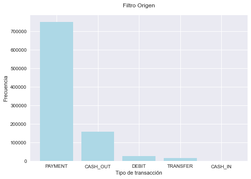

```python
counts = type_transacciones_b.value_counts()

plt.bar(counts.index, counts.values,color="lightblue")
plt.title("Filtro Origen")
plt.xlabel("Tipo de transacción")
plt.ylabel("Frecuencia")
plt.savefig('filtro_1.tiff', dpi=300, format='tiff')
plt.show()
```

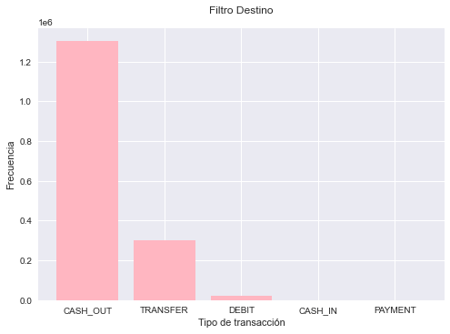

```python
counts = type_transacciones_c.value_counts()

plt.bar(counts.index, counts.values,color="lightpink")
plt.title("Filtro Destino")
plt.xlabel("Tipo de transacción")
plt.ylabel("Frecuencia")
plt.savefig('filtro_2.tiff', dpi=300, format='tiff')
plt.show()
```

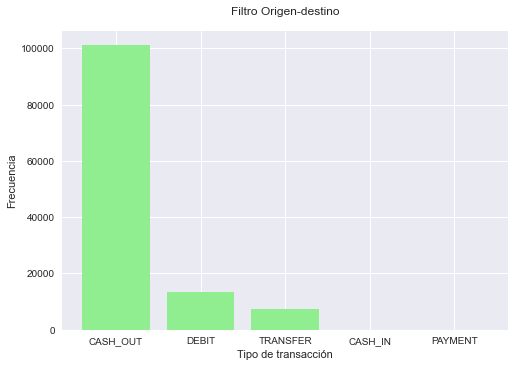

```python
counts = type_transacciones_a.value_counts()

plt.bar(counts.index, counts.values,color="lightgreen")
plt.title("Filtro Origen-destino")
plt.xlabel("Tipo de transacción")
plt.ylabel("Frecuencia")
plt.savefig('filtro_3.tiff', dpi=300, format='tiff')
plt.show()
```

Vamos a ver como se comporta esto con las que se consideran fraude.

1. vemos los casos que son fraude si corresponden con el balance inicial en 0
2. el saldo final en destino sea 0
3. repetir para isfraud=1
4. crea columna con lo que tendría que salir

```python
XY_2_count = len(XY_2)
balan_orig_inicial = len(XY_2[XY_2.oldbalanceOrg == 0])
print("Porcentaje dónde saldo inicial de origen es 0 : " + str(round((balan_orig_inicial/XY_2_count)*100, 2)))
balan_final_dest = len(XY_2[XY_2.newbalanceDest == 0])
print("Porcentaje dónde el saldo final del cliente destino es 0: " + str(round(balan_final_dest/XY_2_count*100, 2)))
```

```
Porcentaje dónde saldo inicial de origen es 0 : 33.04
Porcentaje dónde el saldo final del cliente destino es 0: 38.34
```

```python
# Calcular el número de transacciones con isfraud=1
num_fraud = len(XY_2[XY_2.isFraud == 1])

# Calcular el porcentaje dónde saldo inicial de origen es 0 y isfraud=1
balan_orig_inicial = len(XY_2[(XY_2.oldbalanceOrg == 0) & (XY_2.isFraud == 1)])
percent_orig_inicial = round(balan_orig_inicial / num_fraud * 100, 2)
print(f"Porcentaje dónde saldo inicial de origen es 0 y isfraud=1: {percent_orig_inicial}%")

# Calcular el porcentaje dónde el saldo final del cliente destino es 0 y isfraud=1
balan_final_dest = len(XY_2[(XY_2.newbalanceDest == 0) & (XY_2.isFraud == 1)])
percent_final_dest = round(balan_final_dest / num_fraud * 100, 2)
print(f"Porcentaje dónde el saldo final del cliente destino es 0 y isfraud=1: {percent_final_dest}%")
```

```
Porcentaje dónde saldo inicial de origen es 0 y isfraud=1: 0.5%
Porcentaje dónde el saldo final del cliente destino es 0 y isfraud=1: 49.81%
```

```python
XY_2['balan_final_origen'] = XY_2['oldbalanceOrg'] - XY_2['amount']
XY_2.head()
XY_2['balan_final_dest'] = XY_2['oldbalanceDest'] + XY_2['amount']
XY_2.head()
```

|  | step | type | amount | nameOrig | oldbalanceOrg | newbalanceOrig | nameDest | oldbalanceDest | newbalanceDest | isFraud | isFlaggedFraud | hora | dia | Type2 | balan_final_origen | balan_final_dest |
| --- | --- | --- | --- | --- | --- | --- | --- | --- | --- | --- | --- | --- | --- | --- | --- | --- |
| 0 | 1 | PAYMENT | 9839.64 | C1231006815 | 170136.0 | 160296.36 | M1979787155 | 0.0 | 0.0 | 0 | 0 | 1 | 1 | CM | 160296.36 | 9839.64 |
| 1 | 1 | PAYMENT | 1864.28 | C1666544295 | 21249.0 | 19384.72 | M2044282225 | 0.0 | 0.0 | 0 | 0 | 1 | 1 | CM | 19384.72 | 1864.28 |
| 2 | 1 | TRANSFER | 181.00 | C1305486145 | 181.0 | 0.00 | C553264065 | 0.0 | 0.0 | 1 | 0 | 1 | 1 | CC | 0.00 | 181.00 |
| 3 | 1 | CASH_OUT | 181.00 | C840083671 | 181.0 | 0.00 | C38997010 | 21182.0 | 0.0 | 1 | 0 | 1 | 1 | CC | 0.00 | 21363.00 |
| 4 | 1 | PAYMENT | 11668.14 | C2048537720 | 41554.0 | 29885.86 | M1230701703 | 0.0 | 0.0 | 0 | 0 | 1 | 1 | CM | 29885.86 | 11668.14 |

```python
XY_2['diferencia_balance_orig'] = XY_2['newbalanceOrig'] - XY_2['balan_final_origen']
XY_2.head()
XY_2['diferencia_balance_final'] = XY_2['newbalanceDest'] - XY_2['balan_final_dest']
XY_2.head()
```

|  | step | type | amount | nameOrig | oldbalanceOrg | newbalanceOrig | nameDest | oldbalanceDest | newbalanceDest | isFraud | isFlaggedFraud | hora | dia | Type2 | balan_final_origen | balan_final_dest | diferencia_balance_orig | diferencia_balance_final |
| --- | --- | --- | --- | --- | --- | --- | --- | --- | --- | --- | --- | --- | --- | --- | --- | --- | --- | --- |
| 0 | 1 | PAYMENT | 9839.64 | C1231006815 | 170136.0 | 160296.36 | M1979787155 | 0.0 | 0.0 | 0 | 0 | 1 | 1 | CM | 160296.36 | 9839.64 | 0.0 | -9839.64 |
| 1 | 1 | PAYMENT | 1864.28 | C1666544295 | 21249.0 | 19384.72 | M2044282225 | 0.0 | 0.0 | 0 | 0 | 1 | 1 | CM | 19384.72 | 1864.28 | 0.0 | -1864.28 |
| 2 | 1 | TRANSFER | 181.00 | C1305486145 | 181.0 | 0.00 | C553264065 | 0.0 | 0.0 | 1 | 0 | 1 | 1 | CC | 0.00 | 181.00 | 0.0 | -181.00 |
| 3 | 1 | CASH_OUT | 181.00 | C840083671 | 181.0 | 0.00 | C38997010 | 21182.0 | 0.0 | 1 | 0 | 1 | 1 | CC | 0.00 | 21363.00 | 0.0 | -21363.00 |
| 4 | 1 | PAYMENT | 11668.14 | C2048537720 | 41554.0 | 29885.86 | M1230701703 | 0.0 | 0.0 | 0 | 0 | 1 | 1 | CM | 29885.86 | 11668.14 | 0.0 | -11668.14 |

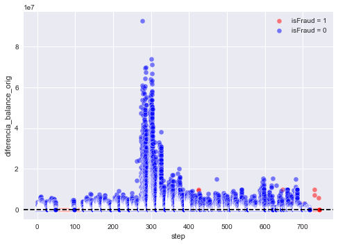

```python
# Subconjunto de datos con isFraud igual a 1
fraud_subset = XY_2[XY_2['isFraud'] == 1]

# Subconjunto de datos con isFraud igual a 0
not_fraud_subset = XY_2[XY_2['isFraud'] == 0]

# Graficar la diferencia en los balances para isFraud igual a 1 y 0
sns.scatterplot(data=fraud_subset, x='step', y='diferencia_balance_orig', color='red', alpha=0.5, label='isFraud = 1')
sns.scatterplot(data=not_fraud_subset, x='step', y='diferencia_balance_orig', color='blue', alpha=0.5, label='isFraud = 0')
plt.axhline(y=0, color='black', linestyle='--')
plt.legend()
plt.savefig('diff_orig.tiff', dpi=300, format='tiff')
plt.show()
```

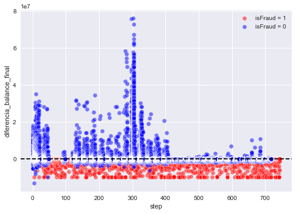

```python
# Subconjunto de datos con isFraud igual a 1
fraud_subset = XY_2[XY_2['isFraud'] == 1]

# Subconjunto de datos con isFraud igual a 0
not_fraud_subset = XY_2[XY_2['isFraud'] == 0]

# Graficar la diferencia en los balances para isFraud igual a 1 y 0
sns.scatterplot(data=fraud_subset, x='step', y='diferencia_balance_final', color='red', alpha=0.5, label='isFraud = 1')
sns.scatterplot(data=not_fraud_subset, x='step', y='diferencia_balance_final', color='blue', alpha=0.5, label='isFraud = 0')
plt.axhline(y=0, color='black', linestyle='--')
plt.legend()
plt.savefig('diff_destino.tiff', dpi=300, format='tiff')
plt.show()
```

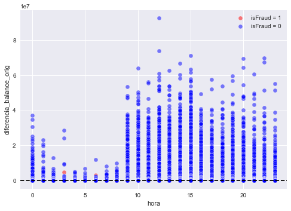

```python
# Subconjunto de datos con isFraud igual a 1
fraud_subset = XY_2[XY_2['isFraud'] == 1]

# Subconjunto de datos con isFraud igual a 0
not_fraud_subset = XY_2[XY_2['isFraud'] == 0]

# Graficar la diferencia en los balances para isFraud igual a 1 y 0
sns.scatterplot(data=fraud_subset, x='hora', y='diferencia_balance_orig', color='red', alpha=0.5, label='isFraud = 1')
sns.scatterplot(data=not_fraud_subset, x='hora', y='diferencia_balance_orig', color='blue', alpha=0.5, label='isFraud = 0')
plt.axhline(y=0, color='black', linestyle='--')
plt.legend()
plt.savefig('diff_orig_2.tiff', dpi=300, format='tiff')
plt.show()
```

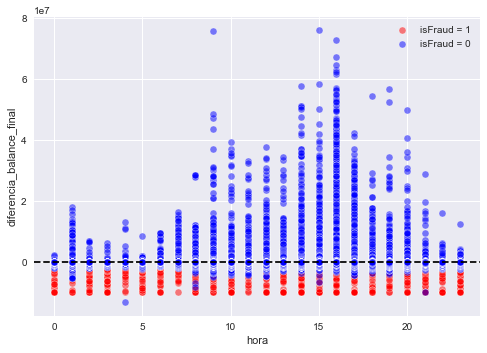

```python
# Subconjunto de datos con isFraud igual a 1
fraud_subset = XY_2[XY_2['isFraud'] == 1]

# Subconjunto de datos con isFraud igual a 0
not_fraud_subset = XY_2[XY_2['isFraud'] == 0]

# Graficar la diferencia en los balances para isFraud igual a 1 y 0
sns.scatterplot(data=fraud_subset, x='hora', y='diferencia_balance_final', color='red', alpha=0.5, label='isFraud = 1')
sns.scatterplot(data=not_fraud_subset, x='hora', y='diferencia_balance_final', color='blue', alpha=0.5, label='isFraud = 0')
plt.axhline(y=0, color='black', linestyle='--')
plt.legend()
plt.savefig('diff_destino_2.tiff', dpi=300, format='tiff')
plt.show()
```

```python
XY_2.head(15)
```

|  | step | type | amount | nameOrig | oldbalanceOrg | newbalanceOrig | nameDest | oldbalanceDest | newbalanceDest | isFraud | isFlaggedFraud | hora | dia | Type2 | balan_final_origen | balan_final_dest | diferencia_balance_orig | diferencia_balance_final |
| --- | --- | --- | --- | --- | --- | --- | --- | --- | --- | --- | --- | --- | --- | --- | --- | --- | --- | --- |
| 0 | 1 | PAYMENT | 9839.64 | C1231006815 | 170136.00 | 160296.36 | M1979787155 | 0.0 | 0.00 | False | False | 1 | 1 | CM | 160296.36 | 9839.64 | 0.000000e+00 | -9839.64 |
| 1 | 1 | PAYMENT | 1864.28 | C1666544295 | 21249.00 | 19384.72 | M2044282225 | 0.0 | 0.00 | False | False | 1 | 1 | CM | 19384.72 | 1864.28 | 0.000000e+00 | -1864.28 |
| 2 | 1 | TRANSFER | 181.00 | C1305486145 | 181.00 | 0.00 | C553264065 | 0.0 | 0.00 | True | False | 1 | 1 | CC | 0.00 | 181.00 | 0.000000e+00 | -181.00 |
| 3 | 1 | CASH_OUT | 181.00 | C840083671 | 181.00 | 0.00 | C38997010 | 21182.0 | 0.00 | True | False | 1 | 1 | CC | 0.00 | 21363.00 | 0.000000e+00 | -21363.00 |
| 4 | 1 | PAYMENT | 11668.14 | C2048537720 | 41554.00 | 29885.86 | M1230701703 | 0.0 | 0.00 | False | False | 1 | 1 | CM | 29885.86 | 11668.14 | 0.000000e+00 | -11668.14 |
| 5 | 1 | PAYMENT | 7817.71 | C90045638 | 53860.00 | 46042.29 | M573487274 | 0.0 | 0.00 | False | False | 1 | 1 | CM | 46042.29 | 7817.71 | 0.000000e+00 | -7817.71 |
| 6 | 1 | PAYMENT | 7107.77 | C154988899 | 183195.00 | 176087.23 | M408069119 | 0.0 | 0.00 | False | False | 1 | 1 | CM | 176087.23 | 7107.77 | 0.000000e+00 | -7107.77 |
| 7 | 1 | PAYMENT | 7861.64 | C1912850431 | 176087.23 | 168225.59 | M633326333 | 0.0 | 0.00 | False | False | 1 | 1 | CM | 168225.59 | 7861.64 | 0.000000e+00 | -7861.64 |
| 8 | 1 | PAYMENT | 4024.36 | C1265012928 | 2671.00 | 0.00 | M1176932104 | 0.0 | 0.00 | False | False | 1 | 1 | CM | -1353.36 | 4024.36 | 1.353360e+03 | -4024.36 |
| 9 | 1 | DEBIT | 5337.77 | C712410124 | 41720.00 | 36382.23 | C195600860 | 41898.0 | 40348.79 | False | False | 1 | 1 | CC | 36382.23 | 47235.77 | 7.275958e-12 | -6886.98 |
| 10 | 1 | DEBIT | 9644.94 | C1900366749 | 4465.00 | 0.00 | C997608398 | 10845.0 | 157982.12 | False | False | 1 | 1 | CC | -5179.94 | 20489.94 | 5.179940e+03 | 137492.18 |
| 11 | 1 | PAYMENT | 3099.97 | C249177573 | 20771.00 | 17671.03 | M2096539129 | 0.0 | 0.00 | False | False | 1 | 1 | CM | 17671.03 | 3099.97 | 0.000000e+00 | -3099.97 |
| 12 | 1 | PAYMENT | 2560.74 | C1648232591 | 5070.00 | 2509.26 | M972865270 | 0.0 | 0.00 | False | False | 1 | 1 | CM | 2509.26 | 2560.74 | 0.000000e+00 | -2560.74 |
| 13 | 1 | PAYMENT | 11633.76 | C1716932897 | 10127.00 | 0.00 | M801569151 | 0.0 | 0.00 | False | False | 1 | 1 | CM | -1506.76 | 11633.76 | 1.506760e+03 | -11633.76 |
| 14 | 1 | PAYMENT | 4098.78 | C1026483832 | 503264.00 | 499165.22 | M1635378213 | 0.0 | 0.00 | False | False | 1 | 1 | CM | 499165.22 | 4098.78 | 0.000000e+00 | -4098.78 |

```python
XY_2['DIF_DEST'] = np.where(XY_2['diferencia_balance_final'] > 0, 0, 1)
```

```python
XY_2.head(15)
```

|  | step | type | amount | nameOrig | oldbalanceOrg | newbalanceOrig | nameDest | oldbalanceDest | newbalanceDest | isFraud | isFlaggedFraud | hora | dia | Type2 | balan_final_origen | balan_final_dest | diferencia_balance_orig | diferencia_balance_final | DIF_DEST |
| --- | --- | --- | --- | --- | --- | --- | --- | --- | --- | --- | --- | --- | --- | --- | --- | --- | --- | --- | --- |
| 0 | 1 | PAYMENT | 9839.64 | C1231006815 | 170136.00 | 160296.36 | M1979787155 | 0.0 | 0.00 | False | False | 1 | 1 | CM | 160296.36 | 9839.64 | 0.000000e+00 | -9839.64 | 1 |
| 1 | 1 | PAYMENT | 1864.28 | C1666544295 | 21249.00 | 19384.72 | M2044282225 | 0.0 | 0.00 | False | False | 1 | 1 | CM | 19384.72 | 1864.28 | 0.000000e+00 | -1864.28 | 1 |
| 2 | 1 | TRANSFER | 181.00 | C1305486145 | 181.00 | 0.00 | C553264065 | 0.0 | 0.00 | True | False | 1 | 1 | CC | 0.00 | 181.00 | 0.000000e+00 | -181.00 | 1 |
| 3 | 1 | CASH_OUT | 181.00 | C840083671 | 181.00 | 0.00 | C38997010 | 21182.0 | 0.00 | True | False | 1 | 1 | CC | 0.00 | 21363.00 | 0.000000e+00 | -21363.00 | 1 |
| 4 | 1 | PAYMENT | 11668.14 | C2048537720 | 41554.00 | 29885.86 | M1230701703 | 0.0 | 0.00 | False | False | 1 | 1 | CM | 29885.86 | 11668.14 | 0.000000e+00 | -11668.14 | 1 |
| 5 | 1 | PAYMENT | 7817.71 | C90045638 | 53860.00 | 46042.29 | M573487274 | 0.0 | 0.00 | False | False | 1 | 1 | CM | 46042.29 | 7817.71 | 0.000000e+00 | -7817.71 | 1 |
| 6 | 1 | PAYMENT | 7107.77 | C154988899 | 183195.00 | 176087.23 | M408069119 | 0.0 | 0.00 | False | False | 1 | 1 | CM | 176087.23 | 7107.77 | 0.000000e+00 | -7107.77 | 1 |
| 7 | 1 | PAYMENT | 7861.64 | C1912850431 | 176087.23 | 168225.59 | M633326333 | 0.0 | 0.00 | False | False | 1 | 1 | CM | 168225.59 | 7861.64 | 0.000000e+00 | -7861.64 | 1 |
| 8 | 1 | PAYMENT | 4024.36 | C1265012928 | 2671.00 | 0.00 | M1176932104 | 0.0 | 0.00 | False | False | 1 | 1 | CM | -1353.36 | 4024.36 | 1.353360e+03 | -4024.36 | 1 |
| 9 | 1 | DEBIT | 5337.77 | C712410124 | 41720.00 | 36382.23 | C195600860 | 41898.0 | 40348.79 | False | False | 1 | 1 | CC | 36382.23 | 47235.77 | 7.275958e-12 | -6886.98 | 1 |
| 10 | 1 | DEBIT | 9644.94 | C1900366749 | 4465.00 | 0.00 | C997608398 | 10845.0 | 157982.12 | False | False | 1 | 1 | CC | -5179.94 | 20489.94 | 5.179940e+03 | 137492.18 | 0 |
| 11 | 1 | PAYMENT | 3099.97 | C249177573 | 20771.00 | 17671.03 | M2096539129 | 0.0 | 0.00 | False | False | 1 | 1 | CM | 17671.03 | 3099.97 | 0.000000e+00 | -3099.97 | 1 |
| 12 | 1 | PAYMENT | 2560.74 | C1648232591 | 5070.00 | 2509.26 | M972865270 | 0.0 | 0.00 | False | False | 1 | 1 | CM | 2509.26 | 2560.74 | 0.000000e+00 | -2560.74 | 1 |
| 13 | 1 | PAYMENT | 11633.76 | C1716932897 | 10127.00 | 0.00 | M801569151 | 0.0 | 0.00 | False | False | 1 | 1 | CM | -1506.76 | 11633.76 | 1.506760e+03 | -11633.76 | 1 |
| 14 | 1 | PAYMENT | 4098.78 | C1026483832 | 503264.00 | 499165.22 | M1635378213 | 0.0 | 0.00 | False | False | 1 | 1 | CM | 499165.22 | 4098.78 | 0.000000e+00 | -4098.78 | 1 |

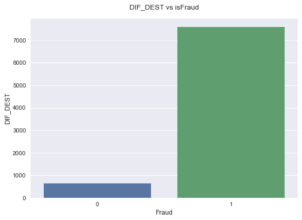

```python
# Filtrar los casos donde isFraud es igual a 1
XY_fraud = XY_2[XY_2['isFraud'] == 1]

# Crear el countplot
sns.countplot(x='DIF_DEST', data=XY_fraud)
# Agregar títulos y etiquetas de los ejes
plt.xlabel('Fraud')
plt.ylabel('DIF_DEST')
plt.title('DIF_DEST vs isFraud')

# Agregar leyenda

plt.savefig('ISFRAUD_DIF_NEGATIVOS.tiff', dpi=300, format='tiff')
# Mostrar el gráfico
plt.show()
```

```python
condicion = (XY_2['amount'] == XY_2['oldbalanceOrg']) & (XY_2['isFraud'] == 1)
num_filas = condicion.sum()

if num_filas > 0:
    print(f"Hay {num_filas} filas donde amount es igual a oldbalanceOrg y isFraud es igual a 1.")
else:
    print("No hay ninguna fila donde amount sea igual a oldbalanceOrg y isFraud sea igual a 1.")
```

```
Hay 8034 filas donde amount es igual a oldbalanceOrg y isFraud es igual a 1.
```

```python
# Crear nueva columna que indica si amount es igual a oldbalanceOrg
XY_2['igualdad'] = (XY_2['amount'] == XY_2['oldbalanceOrg']).astype(int)

# Verificar el resultado
print(XY_2[['amount', 'oldbalanceOrg', 'igualdad']].head())
```

```
     amount  oldbalanceOrg  igualdad
0   9839.64       170136.0         0
1   1864.28        21249.0         0
2    181.00          181.0         1
3    181.00          181.0         1
4  11668.14        41554.0         0
```

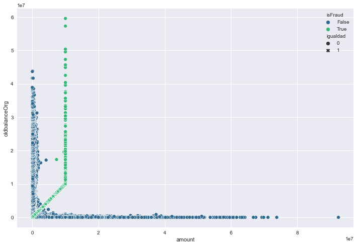

```python
# Graficar la relación entre "amount" y "oldbalanceOrg", y el valor de "isFraud"
plt.figure(figsize=(12,8))
sns.scatterplot(data=XY_2, x='amount', y='oldbalanceOrg', hue='isFraud', style='igualdad', palette='viridis')
plt.savefig('SCATTER_AMOUNT_OLDB.tiff', dpi=300, format='tiff')
```

# 6.2. MACHINE LEARNING. MODELOS DE APRENDIZAJE AUTOMÁTICO SUPERVISADO

```python
df=XY_2.copy()
```

```python
data = df[(df['type'] == 'CASH_OUT') | (df['type'] == 'TRANSFER')| (df['type'] == 'PAYMENT')| (df['type'] == 'DEBIT')| (df['type'] == 'CASH_IN')]
fraud_cashout_and_transfer = data[data['isFraud'] == 1]

num_cash_out = data.groupby(['type'])['type'].count()['CASH_OUT']
num_transfer = data.groupby(['type'])['type'].count()['TRANSFER']
num_payment = data.groupby(['type'])['type'].count()['PAYMENT']
num_debit = data.groupby(['type'])['type'].count()['DEBIT']
num_cashin = data.groupby(['type'])['type'].count()['CASH_IN']
num_fraud_cash_out = fraud_cashout_and_transfer.groupby(['type'])['type'].count()['CASH_OUT']
num_fraud_transfer = fraud_cashout_and_transfer.groupby(['type'])['type'].count()['TRANSFER']

print("Número de transacciones de cash out: ", num_cash_out)
print("Número de transacciones de transfer: ", num_transfer)
print("Número de transacciones de payment: ", num_payment)
print("Número de transacciones de debit: ", num_debit)
print("Número de transacciones de cashin: ", num_cashin)
print("Número de transacciones fraudulentas de cash out: ", num_fraud_cash_out)
print("Número de transacciones fraudulentas de transfer: ", num_fraud_transfer)
```

```
Número de transacciones de cash out:  2237500
Número de transacciones de transfer:  532909
Número de transacciones de payment:  2151495
Número de transacciones de debit:  41432
Número de transacciones de cashin:  1399284
Número de transacciones fraudulentas de cash out:  4116
Número de transacciones fraudulentas de transfer:  4097
```

```python
#como tengo varias variables dicotómicas no puedo evaluar su relacion con las numericas con pearson, asique decimos calcular:
#1. CHI-CUADRADO ENTRE VARIABLES CATEGORICAS
from scipy.stats import chi2_contingency

# Crear matriz de contingencia para cada variable
var_list = ['DIF_DEST', 'igualdad','Type2']
cont_tables = {}
for var in var_list:
    cont_table = pd.crosstab(XY_2[var], XY_2['isFraud'])
    cont_tables[var] = cont_table

# Calcular la prueba de chi-cuadrado para cada variable
chi2_dict = {}
for var, table in cont_tables.items():
    chi2, pval, dof, expected = chi2_contingency(table)
    chi2_dict[var] = (chi2, pval, dof, expected)


for var, (chi2, pval, dof, expected) in chi2_dict.items():
    print(f'Variable: {var}')
    print(f'Chi2: {chi2}')
    print(f'P-valor: {pval}')
    print(f'Degrees of Freedom: {dof}')
    print(f'Expected: \n{expected}\n')
```

```
Variable: DIF_DEST
Chi2: 60.736244369927654
P-valor: 6.525752174958566e-15
Degrees of Freedom: 1
Expected:
[[6.55463820e+05 8.47179659e+02]
 [5.69894318e+06 7.36582034e+03]]

Variable: igualdad
Chi2: 6222997.529549603
P-valor: 0.0
Degrees of Freedom: 1
Expected:
[[6.34638337e+06 8.20262955e+03]
 [8.02362955e+03 1.03704515e+01]]

Variable: Type2
Chi2: 4199.99328862616
P-valor: 0.0
Degrees of Freedom: 1
Expected:
[[4.20568919e+06 5.43580626e+03]
 [2.14871781e+06 2.77719374e+03]]
```

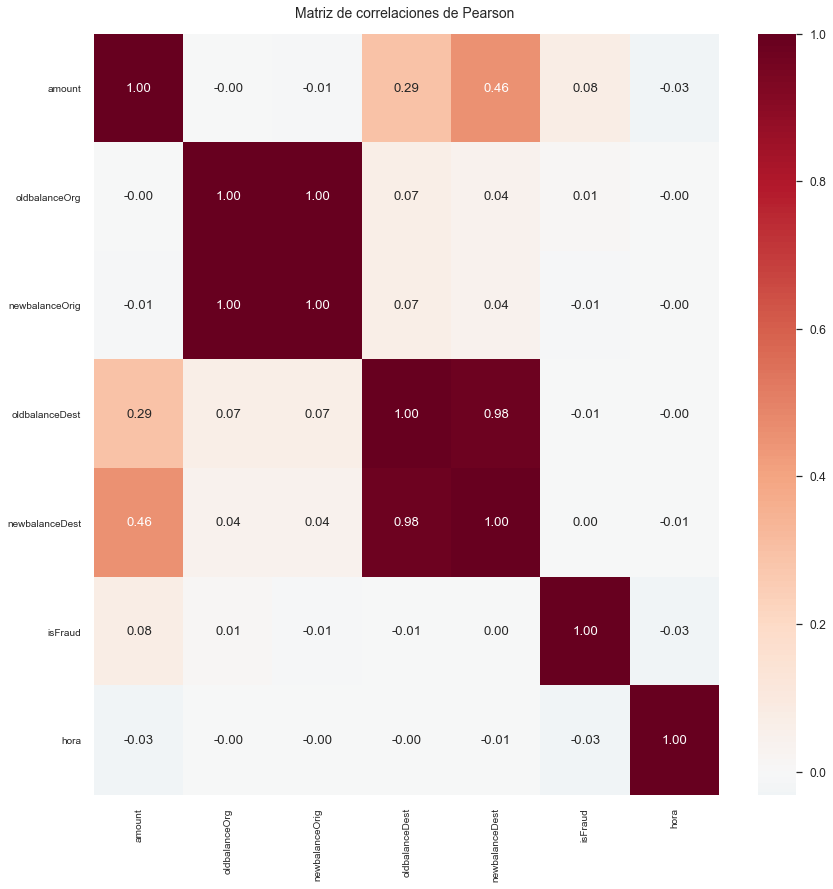

```python
data = df[['amount', 'oldbalanceOrg', 'newbalanceOrig', 'oldbalanceDest', 'newbalanceDest', 'isFraud', 'hora']]

matriz_correlaciones = data.corr(method='pearson')

plt.figure(figsize=(14, 14))
sns.set(font_scale=1.1)
sns.heatmap(matriz_correlaciones, annot=True, cmap='RdBu_r', center=0, fmt='.2f',
            xticklabels=matriz_correlaciones.columns.values,
            yticklabels=matriz_correlaciones.columns.values)
plt.xticks(rotation=90, fontsize=10)
plt.yticks(rotation=0, fontsize=10)
plt.title('Matriz de correlaciones de Pearson ', fontsize=14)
plt.savefig('matriz_correlación_DEFINITIVA.tiff', dpi=300, format='tiff')
plt.show()
```

```python
#pip install imbalanced-learn
from sklearn.model_selection import train_test_split
```

```python
# check version number
import imblearn
print(imblearn.__version__)
```

```
0.10.1
```

```python
#comprobamso si hay nan en alguna columna
df.isna().sum()
```

```
step                        0
type                        0
amount                      0
nameOrig                    0
oldbalanceOrg               0
newbalanceOrig              0
nameDest                    0
oldbalanceDest              0
newbalanceDest              0
isFraud                     0
isFlaggedFraud              0
hora                        0
dia                         0
Type2                       0
balan_final_origen          0
balan_final_dest            0
diferencia_balance_orig     0
diferencia_balance_final    0
DIF_DEST                    0
igualdad                    0
dtype: int64
```

Aplicamos One Hot Encoding en la variable "type" y "type2" para poder trabajar con estas variables categóricas. Spoiler: con PCA veremos si estas variables son relevante o no.

```python
dummies = pd.get_dummies(df.type, prefix='type')
df = pd.concat([df, dummies], axis=1)
dummies = pd.get_dummies(df.Type2, prefix='Type2')
df = pd.concat([df, dummies], axis=1)
df.head()
```

|  | step | type | amount | nameOrig | oldbalanceOrg | newbalanceOrig | nameDest | oldbalanceDest | newbalanceDest | isFraud | ... | diferencia_balance_final | DIF_DEST | igualdad | type_CASH_IN | type_CASH_OUT | type_DEBIT | type_PAYMENT | type_TRANSFER | Type2_CC | Type2_CM |
| --- | --- | --- | --- | --- | --- | --- | --- | --- | --- | --- | --- | --- | --- | --- | --- | --- | --- | --- | --- | --- | --- |
| 0 | 1 | PAYMENT | 9839.64 | C1231006815 | 170136.0 | 160296.36 | M1979787155 | 0.0 | 0.0 | 0 | ... | -9839.64 | 1 | 0 | 0 | 0 | 0 | 1 | 0 | 0 | 1 |
| 1 | 1 | PAYMENT | 1864.28 | C1666544295 | 21249.0 | 19384.72 | M2044282225 | 0.0 | 0.0 | 0 | ... | -1864.28 | 1 | 0 | 0 | 0 | 0 | 1 | 0 | 0 | 1 |
| 2 | 1 | TRANSFER | 181.00 | C1305486145 | 181.0 | 0.00 | C553264065 | 0.0 | 0.0 | 1 | ... | -181.00 | 1 | 1 | 0 | 0 | 0 | 0 | 1 | 1 | 0 |
| 3 | 1 | CASH_OUT | 181.00 | C840083671 | 181.0 | 0.00 | C38997010 | 21182.0 | 0.0 | 1 | ... | -21363.00 | 1 | 1 | 0 | 1 | 0 | 0 | 0 | 1 | 0 |
| 4 | 1 | PAYMENT | 11668.14 | C2048537720 | 41554.0 | 29885.86 | M1230701703 | 0.0 | 0.0 | 0 | ... | -11668.14 | 1 | 0 | 0 | 0 | 0 | 1 | 0 | 0 | 1 |

5 rows × 27 columns

```python
df.info()
```

```
<class 'pandas.core.frame.DataFrame'>
RangeIndex: 6362620 entries, 0 to 6362619
Data columns (total 27 columns):
 #   Column                    Dtype
---  ------                    -----
 0   step                      int64
 1   type                      category
 2   amount                    float64
 3   nameOrig                  category
 4   oldbalanceOrg             float64
 5   newbalanceOrig            float64
 6   nameDest                  category
 7   oldbalanceDest            float64
 8   newbalanceDest            float64
 9   isFraud                   bool
```

[output cut: 19 more lines]

```python
#Eliminamos las variables categóricas "nameOrig" y "nameDest". También eliminamos la variable "type" ya que hemos aplicado previamente one hot encoding en esta misma variable:
df = df.drop(columns=["type","nameOrig", "nameDest","step","Type2","dia","balan_final_origen","balan_final_dest","diferencia_balance_orig","diferencia_balance_final","DIF_DEST","igualdad"])

df.head()
```

|  | amount | oldbalanceOrg | newbalanceOrig | oldbalanceDest | newbalanceDest | isFraud | isFlaggedFraud | hora | type_CASH_IN | type_CASH_OUT | type_DEBIT | type_PAYMENT | type_TRANSFER | Type2_CC | Type2_CM |
| --- | --- | --- | --- | --- | --- | --- | --- | --- | --- | --- | --- | --- | --- | --- | --- |
| 0 | 9839.64 | 170136.0 | 160296.36 | 0.0 | 0.0 | 0 | 0 | 1 | 0 | 0 | 0 | 1 | 0 | 0 | 1 |
| 1 | 1864.28 | 21249.0 | 19384.72 | 0.0 | 0.0 | 0 | 0 | 1 | 0 | 0 | 0 | 1 | 0 | 0 | 1 |
| 2 | 181.00 | 181.0 | 0.00 | 0.0 | 0.0 | 1 | 0 | 1 | 0 | 0 | 0 | 0 | 1 | 1 | 0 |
| 3 | 181.00 | 181.0 | 0.00 | 21182.0 | 0.0 | 1 | 0 | 1 | 0 | 1 | 0 | 0 | 0 | 1 | 0 |
| 4 | 11668.14 | 41554.0 | 29885.86 | 0.0 | 0.0 | 0 | 0 | 1 | 0 | 0 | 0 | 1 | 0 | 0 | 1 |

```python
df.info()
```

```
<class 'pandas.core.frame.DataFrame'>
RangeIndex: 6362620 entries, 0 to 6362619
Data columns (total 15 columns):
 #   Column          Dtype
---  ------          -----
 0   amount          float64
 1   oldbalanceOrg   float64
 2   newbalanceOrig  float64
 3   oldbalanceDest  float64
 4   newbalanceDest  float64
 5   isFraud         bool
 6   isFlaggedFraud  bool
 7   hora            int64
 8   type_CASH_IN    uint8
 9   type_CASH_OUT   uint8
 10  type_DEBIT      uint8
 11  type_PAYMENT    uint8
 12  type_TRANSFER   uint8
 13  Type2_CC        uint8
 14  Type2_CM        uint8
dtypes: bool(2), float64(5), int64(1), uint8(7)
memory usage: 345.9 MB
```

```python
X = df.drop('isFraud', axis=1)
Y = df['isFraud']
```

Normalizamos los datos antes de aplicar PCA:

```python
from sklearn.preprocessing import StandardScaler
# Seleccionamos las columnas que queremos normalizar
columnas_a_normalizar = ['amount','oldbalanceOrg','newbalanceOrig','oldbalanceDest','newbalanceDest','isFlaggedFraud','hora','type_CASH_IN','type_CASH_OUT','type_DEBIT','type_PAYMENT','type_TRANSFER','Type2_CC','Type2_CM']
datos_normalizados = X[columnas_a_normalizar]

# Creamos un objeto StandardScaler y lo ajustamos a los datos
scaler = StandardScaler().fit(datos_normalizados)

# Aplicamos la normalización a los datos
datos_normalizados = scaler.transform(datos_normalizados)

# Creamos un nuevo DataFrame con los datos normalizados y los nombres de columna originales
X_n = pd.DataFrame(datos_normalizados, columns=columnas_a_normalizar)
```

```python
from sklearn.decomposition import PCA

pca= PCA(n_components=3)
X_a = pca.fit_transform(X_n)
X_b = pca.fit_transform(X_n[['hora','amount','oldbalanceOrg','newbalanceOrig','oldbalanceDest','newbalanceDest','isFlaggedFraud']])# sin las variables type
X_c = pca.fit_transform(X_n[['amount','isFlaggedFraud','type_CASH_IN','type_CASH_OUT','type_DEBIT','type_PAYMENT','type_TRANSFER']])
X_d = pca.fit_transform(X_n[['oldbalanceOrg','newbalanceOrig','oldbalanceDest','newbalanceDest','isFlaggedFraud','type_CASH_IN','type_CASH_OUT','type_DEBIT','type_PAYMENT','type_TRANSFER']])
X_e = pca.fit_transform(X_n[['oldbalanceOrg','newbalanceOrig','oldbalanceDest','newbalanceDest','isFlaggedFraud']])
X_f = pca.fit_transform(X_n[['amount','hora','oldbalanceOrg','newbalanceOrig','oldbalanceDest','newbalanceDest']])
X_g = pca.fit_transform(X_n[['amount','oldbalanceOrg','newbalanceOrig','oldbalanceDest','newbalanceDest']])
X_h = pca.fit_transform(X_n[['amount','oldbalanceOrg','newbalanceOrig','oldbalanceDest','newbalanceDest','type_CASH_IN','type_CASH_OUT','type_DEBIT','type_PAYMENT','type_TRANSFER','Type2_CC','Type2_CM']])
#print(pca.explained_variance_ratio_)
```

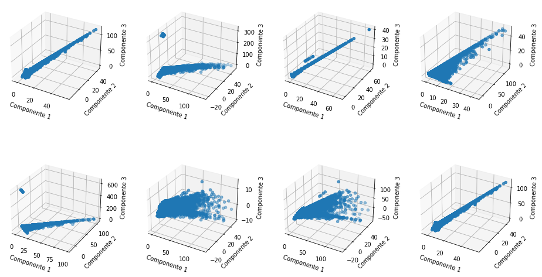

```python
from mpl_toolkits.mplot3d import Axes3D

fig, axes = plt.subplots(nrows=2, ncols=4, figsize=(16, 8), subplot_kw={'projection': '3d'})

X_list = [X_a, X_b, X_c, X_d, X_e, X_f, X_g, X_h]

for i, ax in enumerate(axes.flat):
    if i < len(X_list):
        X = X_list[i]
        ax.scatter(X[:, 0], X[:, 1], X[:, 2])
        ax.set_xlabel('Componente 1')
        ax.set_ylabel('Componente 2')
        ax.set_zlabel('Componente 3')
    else:
        ax.axis('off')  # Hide empty subplot

plt.subplots_adjust(hspace=0.5, wspace=0.2)
plt.savefig('PCA.tiff', dpi=300, format='tiff')
plt.show()
```

Dividimos el dataset en 70% para train y 30% para test.

```python
X_train_a, X_test_a, Y_train_a, Y_test_a = train_test_split(X_a, Y, test_size=0.3)
X_train_b, X_test_b, Y_train_b, Y_test_b = train_test_split(X_b, Y, test_size=0.3)
X_train_c, X_test_c, Y_train_c, Y_test_c = train_test_split(X_c, Y, test_size=0.3)
X_train_d, X_test_d, Y_train_d, Y_test_d = train_test_split(X_d, Y, test_size=0.3)
X_train_e, X_test_e, Y_train_e, Y_test_e = train_test_split(X_e, Y, test_size=0.3)
X_train_f, X_test_f, Y_train_f, Y_test_f = train_test_split(X_f, Y, test_size=0.3)
X_train_g, X_test_g, Y_train_g, Y_test_g = train_test_split(X_g, Y, test_size=0.3)
X_train_h, X_test_h, Y_train_h, Y_test_h = train_test_split(X_h, Y, test_size=0.3)
```

Aplicamos oversampling(SMOTE) y undersampling(RandomUnderSampler) en los dataset de entrenamiento para balancear los dataset de train:

```python
from collections import Counter
from sklearn.datasets import make_classification
from imblearn.over_sampling import SMOTE
from imblearn.under_sampling import RandomUnderSampler
from imblearn.pipeline import Pipeline
from matplotlib import pyplot
from numpy import where

over = SMOTE(sampling_strategy=0.1) # aplicamos oversampling
under = RandomUnderSampler(sampling_strategy=0.5) # aplicamos undersampling
steps = [('o', over), ('u', under)]
pipeline = Pipeline(steps=steps)
# transform the dataset
X_t_a, Y_t_a = pipeline.fit_resample(X_train_a, Y_train_a)
X_t_b, Y_t_b = pipeline.fit_resample(X_train_b, Y_train_b)
X_t_c, Y_t_c = pipeline.fit_resample(X_train_c, Y_train_c)
X_t_d, Y_t_d = pipeline.fit_resample(X_train_d, Y_train_d)
X_t_e, Y_t_e = pipeline.fit_resample(X_train_e, Y_train_e)
X_t_f, Y_t_f = pipeline.fit_resample(X_train_f, Y_train_f)
X_t_g, Y_t_g = pipeline.fit_resample(X_train_g, Y_train_g)
X_t_h, Y_t_h = pipeline.fit_resample(X_train_h, Y_train_h)
```

Aplicamos KNN con PCA al conjunto -a- de variables:

```python
from sklearn.datasets import load_iris
from sklearn.neighbors import KNeighborsClassifier
from sklearn.model_selection import train_test_split
from sklearn.metrics import accuracy_score
from sklearn.metrics import classification_report,confusion_matrix,accuracy_score, roc_curve, auc, precision_score

# Crear un modelo KNN con k=3 vecinos cercanos
model = KNeighborsClassifier(n_neighbors=3)

# Entrenar el modelo utilizando el conjunto de entrenamiento
model.fit(X_t_a, Y_t_a)

# Predecir las etiquetas de clase para el conjunto de prueba
y_pred = model.predict(X_test_a)

# Evaluar la precisión del modelo
accuracy = accuracy_score(Y_test_a, y_pred)
print("Precisión:", accuracy)

# Evaluacion modelo
CM_RF = confusion_matrix(Y_test_a,y_pred)
CR_RF = classification_report(Y_test_a,y_pred)
fprRF, recallRF, thresholdsRF = roc_curve(Y_test_a, y_pred)
AUC_RF = auc(fprRF, recallRF)

resultsRF = {"Confusion Matrix":CM_RF,"Classification Report":CR_RF,"Area Under Curve":AUC_RF}

# sprint resultado

for measure in resultsRF:
    print(measure,": \n",resultsRF[measure])
```

```
Precisión: 0.9890909719580927
Confusion Matrix :
 [[1885853   20452]
 [    371    2110]]
Classification Report :
               precision    recall  f1-score   support

       False       1.00      0.99      0.99   1906305
        True       0.09      0.85      0.17      2481

    accuracy                           0.99   1908786
   macro avg       0.55      0.92      0.58   1908786
weighted avg       1.00      0.99      0.99   1908786

Area Under Curve :
 0.9198674571435126
```

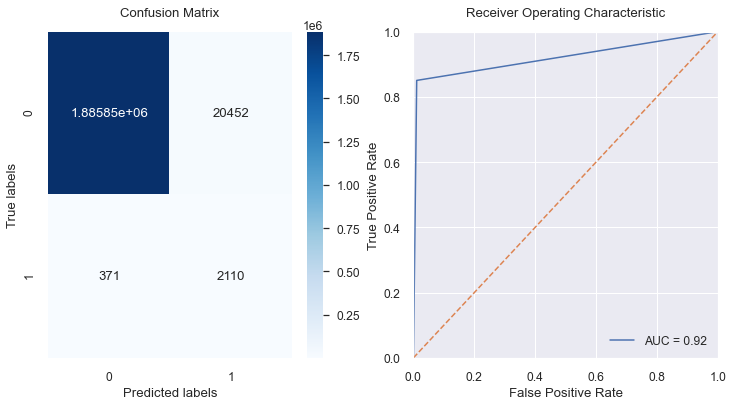

```python
# Obtener las probabilidades de la clase positiva para calcular la curva ROC
y_prob = model.predict_proba(X_test_a)[:, 1]

# Calcular la matriz de confusión
cm = confusion_matrix(Y_test_a, y_pred)

# Crear la figura y los subplots
fig, (ax1, ax2) = plt.subplots(1, 2, figsize=(12, 6))

# Crear la matriz de confusión
sns.heatmap(cm, annot=True, cmap='Blues', fmt='g', ax=ax1)

# Configurar las etiquetas de los ejes
ax1.set_xlabel('Predicted labels')
ax1.set_ylabel('True labels')
ax1.set_title('Confusion Matrix')

# Graficar la curva ROC
ax2.plot(fprRF, recallRF, label='AUC = %0.2f' % AUC_RF )
ax2.plot([0, 1], [0, 1], linestyle='--')
ax2.set_xlim([0.0, 1.0])
ax2.set_ylim([0.0, 1.0])
ax2.set_xlabel('False Positive Rate')
ax2.set_ylabel('True Positive Rate')
ax2.set_title('Receiver Operating Characteristic')
ax2.legend(loc="lower right")

# Mostrar la figura
plt.savefig('knn_Xa.tiff', dpi=300, format='tiff')
plt.show()
```

Aplicamos KNN con PCA al conjunto -b- de variables:

```python
# Crear un modelo KNN con k=3 vecinos cercanos
model = KNeighborsClassifier(n_neighbors=3)

# Entrenar el modelo utilizando el conjunto de entrenamiento
model.fit(X_t_b, Y_t_b)

# Predecir las etiquetas de clase para el conjunto de prueba
y_pred = model.predict(X_test_b)

# Evaluar la precisión del modelo
accuracy = accuracy_score(Y_test_b, y_pred)
print("Precisión:", accuracy)

# Evaluacion modelo
CM_RF = confusion_matrix(Y_test_b,y_pred)
CR_RF = classification_report(Y_test_b,y_pred)
fprRF, recallRF, thresholdsRF = roc_curve(Y_test_b, y_pred)
AUC_RF = auc(fprRF, recallRF)

resultsRF = {"Confusion Matrix":CM_RF,"Classification Report":CR_RF,"Area Under Curve":AUC_RF}

# sprint resultado

for measure in resultsRF:
    print(measure,": \n",resultsRF[measure])
```

```
Precisión: 0.9784617028834034
Confusion Matrix :
 [[1865791   40573]
 [    539    1883]]
Classification Report :
               precision    recall  f1-score   support

       False       1.00      0.98      0.99   1906364
        True       0.04      0.78      0.08      2422

    accuracy                           0.98   1908786
   macro avg       0.52      0.88      0.54   1908786
weighted avg       1.00      0.98      0.99   1908786

Area Under Curve :
 0.8780868617330817
```

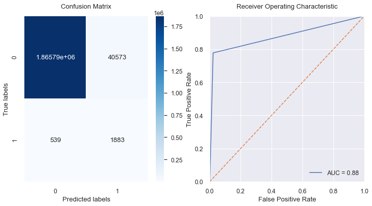

```python
# Obtener las probabilidades de la clase positiva para calcular la curva ROC
y_prob = model.predict_proba(X_test_b)[:, 1]

# Calcular la matriz de confusión
cm = confusion_matrix(Y_test_b, y_pred)

# Crear la figura y los subplots
fig, (ax1, ax2) = plt.subplots(1, 2, figsize=(12, 6))

# Crear la matriz de confusión
sns.heatmap(cm, annot=True, cmap='Blues', fmt='g', ax=ax1)

# Configurar las etiquetas de los ejes
ax1.set_xlabel('Predicted labels')
ax1.set_ylabel('True labels')
ax1.set_title('Confusion Matrix')


# Graficar la curva ROC
ax2.plot(fprRF, recallRF, label='AUC = %0.2f' % AUC_RF )
ax2.plot([0, 1], [0, 1], linestyle='--')
ax2.set_xlim([0.0, 1.0])
ax2.set_ylim([0.0, 1.0])
ax2.set_xlabel('False Positive Rate')
ax2.set_ylabel('True Positive Rate')
ax2.set_title('Receiver Operating Characteristic')
ax2.legend(loc="lower right")

# Mostrar la figura
plt.savefig('knn_Xb.tiff', dpi=300, format='tiff')
plt.show()
```

Aplicamos KNN con PCA al conjunto -c- de variables:

```python
# Crear un modelo KNN con k=3 vecinos cercanos
model = KNeighborsClassifier(n_neighbors=3)

# Entrenar el modelo utilizando el conjunto de entrenamiento
model.fit(X_t_c, Y_t_c)

# Predecir las etiquetas de clase para el conjunto de prueba
y_pred = model.predict(X_test_c)

# Evaluar la precisión del modelo
accuracy = accuracy_score(Y_test_c, y_pred)
print("Precisión:", accuracy)

# Evaluacion modelo
CM_RF = confusion_matrix(Y_test_c,y_pred)
CR_RF = classification_report(Y_test_c,y_pred)
fprRF, recallRF, thresholdsRF = roc_curve(Y_test_c, y_pred)
AUC_RF = auc(fprRF, recallRF)

resultsRF = {"Confusion Matrix":CM_RF,"Classification Report":CR_RF,"Area Under Curve":AUC_RF}

# sprint resultado

for measure in resultsRF:
    print(measure,": \n",resultsRF[measure])
```

```
Precisión: 0.8898346907406068
Confusion Matrix :
 [[1697081  209220]
 [   1062    1423]]
Classification Report :
               precision    recall  f1-score   support

       False       1.00      0.89      0.94   1906301
        True       0.01      0.57      0.01      2485

    accuracy                           0.89   1908786
   macro avg       0.50      0.73      0.48   1908786
weighted avg       1.00      0.89      0.94   1908786

Area Under Curve :
 0.7314419985509518
```

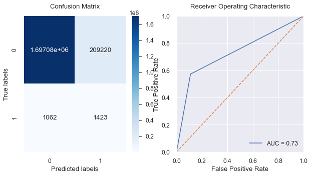

```python
# Obtener las probabilidades de la clase positiva para calcular la curva ROC
y_prob = model.predict_proba(X_test_c)[:, 1]

# Calcular la matriz de confusión
cm = confusion_matrix(Y_test_c, y_pred)

# Crear la figura y los subplots
fig, (ax1, ax2) = plt.subplots(1, 2, figsize=(10, 5))

# Crear la matriz de confusión
sns.heatmap(cm, annot=True, cmap='Blues', fmt='g', ax=ax1)

# Configurar las etiquetas de los ejes
ax1.set_xlabel('Predicted labels')
ax1.set_ylabel('True labels')
ax1.set_title('Confusion Matrix')


# Graficar la curva ROC
ax2.plot(fprRF, recallRF, label='AUC = %0.2f' % AUC_RF )
ax2.plot([0, 1], [0, 1], linestyle='--')
ax2.set_xlim([0.0, 1.0])
ax2.set_ylim([0.0, 1.0])
ax2.set_xlabel('False Positive Rate')
ax2.set_ylabel('True Positive Rate')
ax2.set_title('Receiver Operating Characteristic')
ax2.legend(loc="lower right")

# Mostrar la figura
plt.savefig('knn_Xc.tiff', dpi=300, format='tiff')
plt.show()
```

Aplicamos KNN con PCA al conjunto -d- de variables:

```python
# Crear un modelo KNN con k=3 vecinos cercanos
model = KNeighborsClassifier(n_neighbors=3)

# Entrenar el modelo utilizando el conjunto de entrenamiento
model.fit(X_t_d, Y_t_d)

# Predecir las etiquetas de clase para el conjunto de prueba
y_pred = model.predict(X_test_d)

# Evaluar la precisión del modelo
accuracy = accuracy_score(Y_test_d, y_pred)
print("Precisión:", accuracy)

# Evaluacion modelo
CM_RF = confusion_matrix(Y_test_d,y_pred)
CR_RF = classification_report(Y_test_d,y_pred)
fprRF, recallRF, thresholdsRF = roc_curve(Y_test_d, y_pred)
AUC_RF = auc(fprRF, recallRF)

resultsRF = {"Confusion Matrix":CM_RF,"Classification Report":CR_RF,"Area Under Curve":AUC_RF}

# sprint resultado

for measure in resultsRF:
    print(measure,": \n",resultsRF[measure])
```

```
Precisión: 0.9764525724727654
Confusion Matrix :
 [[1861822   44503]
 [    444    2017]]
Classification Report :
               precision    recall  f1-score   support

       False       1.00      0.98      0.99   1906325
        True       0.04      0.82      0.08      2461

    accuracy                           0.98   1908786
   macro avg       0.52      0.90      0.54   1908786
weighted avg       1.00      0.98      0.99   1908786

Area Under Curve :
 0.8981203083793113
```

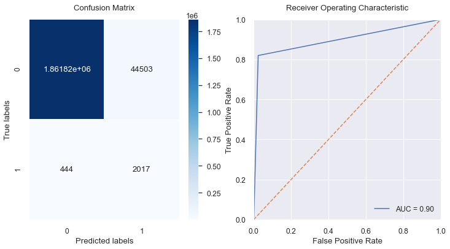

```python
# Obtener las probabilidades de la clase positiva para calcular la curva ROC
y_prob = model.predict_proba(X_test_d)[:, 1]

# Calcular la matriz de confusión
cm = confusion_matrix(Y_test_d, y_pred)

# Crear la figura y los subplots
fig, (ax1, ax2) = plt.subplots(1, 2, figsize=(12, 6))

# Crear la matriz de confusión
sns.heatmap(cm, annot=True, cmap='Blues', fmt='g', ax=ax1)

# Configurar las etiquetas de los ejes
ax1.set_xlabel('Predicted labels')
ax1.set_ylabel('True labels')
ax1.set_title('Confusion Matrix')


# Graficar la curva ROC
ax2.plot(fprRF, recallRF, label='AUC = %0.2f' % AUC_RF )
ax2.plot([0, 1], [0, 1], linestyle='--')
ax2.set_xlim([0.0, 1.0])
ax2.set_ylim([0.0, 1.0])
ax2.set_xlabel('False Positive Rate')
ax2.set_ylabel('True Positive Rate')
ax2.set_title('Receiver Operating Characteristic')
ax2.legend(loc="lower right")

# Mostrar la figura
plt.savefig('knn_Xd.tiff', dpi=300, format='tiff')
plt.show()
```

Aplicamos KNN con PCA al conjunto -e- de variables:

```python
# Crear un modelo KNN con k=3 vecinos cercanos
model = KNeighborsClassifier(n_neighbors=3)

# Entrenar el modelo utilizando el conjunto de entrenamiento
model.fit(X_t_e, Y_t_e)

# Predecir las etiquetas de clase para el conjunto de prueba
y_pred = model.predict(X_test_e)

# Evaluar la precisión del modelo
accuracy = accuracy_score(Y_test_e, y_pred)
print("Precisión:", accuracy)

# Evaluacion modelo
CM_RF = confusion_matrix(Y_test_e,y_pred)
CR_RF = classification_report(Y_test_e,y_pred)
fprRF, recallRF, thresholdsRF = roc_curve(Y_test_e, y_pred)
AUC_RF = auc(fprRF, recallRF)

resultsRF = {"Confusion Matrix":CM_RF,"Classification Report":CR_RF,"Area Under Curve":AUC_RF}

# sprint resultado

for measure in resultsRF:
    print(measure,": \n",resultsRF[measure])
```

```
Precisión: 0.9505701529663356
Confusion Matrix :
 [[1812710   93516]
 [    835    1725]]
Classification Report :
               precision    recall  f1-score   support

       False       1.00      0.95      0.97   1906226
        True       0.02      0.67      0.04      2560

    accuracy                           0.95   1908786
   macro avg       0.51      0.81      0.50   1908786
weighted avg       1.00      0.95      0.97   1908786

Area Under Curve :
 0.812384966789418
```

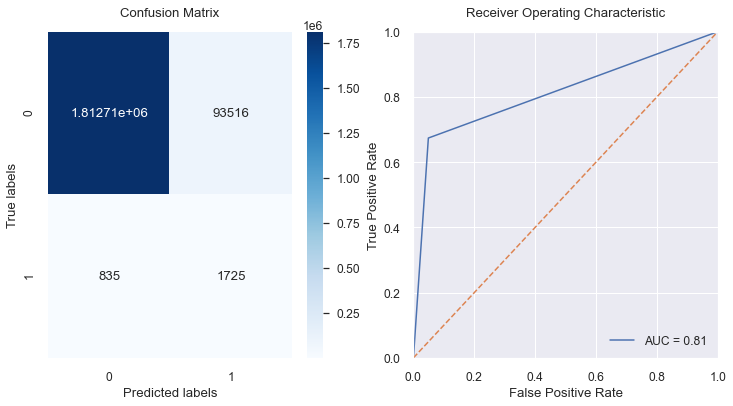

```python
# Obtener las probabilidades de la clase positiva para calcular la curva ROC
y_prob = model.predict_proba(X_test_e)[:, 1]

# Calcular la matriz de confusión
cm = confusion_matrix(Y_test_e, y_pred)

# Crear la figura y los subplots
fig, (ax1, ax2) = plt.subplots(1, 2, figsize=(12, 6))

# Crear la matriz de confusión
sns.heatmap(cm, annot=True, cmap='Blues', fmt='g', ax=ax1)

# Configurar las etiquetas de los ejes
ax1.set_xlabel('Predicted labels')
ax1.set_ylabel('True labels')
ax1.set_title('Confusion Matrix')

# Graficar la curva ROC
ax2.plot(fprRF, recallRF, label='AUC = %0.2f' % AUC_RF )
ax2.plot([0, 1], [0, 1], linestyle='--')
ax2.set_xlim([0.0, 1.0])
ax2.set_ylim([0.0, 1.0])
ax2.set_xlabel('False Positive Rate')
ax2.set_ylabel('True Positive Rate')
ax2.set_title('Receiver Operating Characteristic')
ax2.legend(loc="lower right")

# Mostrar la figura
plt.savefig('knn_Xe.tiff', dpi=300, format='tiff')
plt.show()
```

Aplicamos KNN con PCA al conjunto -f- de variables:

```python
# Crear un modelo KNN con k=3 vecinos cercanos
model = KNeighborsClassifier(n_neighbors=3)

# Entrenar el modelo utilizando el conjunto de entrenamiento
model.fit(X_t_f, Y_t_f)

# Predecir las etiquetas de clase para el conjunto de prueba
y_pred = model.predict(X_test_f)

# Evaluar la precisión del modelo
accuracy = accuracy_score(Y_test_f, y_pred)
print("Precisión:", accuracy)

# Evaluacion modelo
CM_RF = confusion_matrix(Y_test_f,y_pred)
CR_RF = classification_report(Y_test_f,y_pred)
fprRF, recallRF, thresholdsRF = roc_curve(Y_test_f, y_pred)
AUC_RF = auc(fprRF, recallRF)

resultsRF = {"Confusion Matrix":CM_RF,"Classification Report":CR_RF,"Area Under Curve":AUC_RF}

# sprint resultado

for measure in resultsRF:
    print(measure,": \n",resultsRF[measure])
```

```
Precisión: 0.978104931616221
Confusion Matrix :
 [[1865033   41299]
 [    494    1960]]
Classification Report :
               precision    recall  f1-score   support

       False       1.00      0.98      0.99   1906332
        True       0.05      0.80      0.09      2454

    accuracy                           0.98   1908786
   macro avg       0.52      0.89      0.54   1908786
weighted avg       1.00      0.98      0.99   1908786

Area Under Curve :
 0.8885159446259158
```

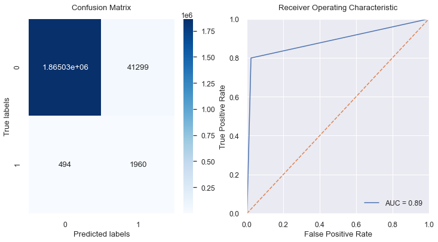

```python
# Obtener las probabilidades de la clase positiva para calcular la curva ROC
y_prob = model.predict_proba(X_test_f)[:, 1]

# Calcular la matriz de confusión
cm = confusion_matrix(Y_test_f, y_pred)

# Crear la figura y los subplots
fig, (ax1, ax2) = plt.subplots(1, 2, figsize=(12, 6))

# Crear la matriz de confusión
sns.heatmap(cm, annot=True, cmap='Blues', fmt='g', ax=ax1)

# Configurar las etiquetas de los ejes
ax1.set_xlabel('Predicted labels')
ax1.set_ylabel('True labels')
ax1.set_title('Confusion Matrix')



# Graficar la curva ROC
ax2.plot(fprRF, recallRF, label='AUC = %0.2f' % AUC_RF )
ax2.plot([0, 1], [0, 1], linestyle='--')
ax2.set_xlim([0.0, 1.0])
ax2.set_ylim([0.0, 1.0])
ax2.set_xlabel('False Positive Rate')
ax2.set_ylabel('True Positive Rate')
ax2.set_title('Receiver Operating Characteristic')
ax2.legend(loc="lower right")

# Mostrar la figura
plt.savefig('knn_Xf.tiff', dpi=300, format='tiff')
plt.show()
```

Aplicamos KNN con PCA al conjunto -g- de variables:

```python
# Crear un modelo KNN con k=3 vecinos cercanos
model = KNeighborsClassifier(n_neighbors=3)

# Entrenar el modelo utilizando el conjunto de entrenamiento
model.fit(X_t_g, Y_t_g)

# Predecir las etiquetas de clase para el conjunto de prueba
y_pred = model.predict(X_test_g)

# Evaluar la precisión del modelo
accuracy = accuracy_score(Y_test_g, y_pred)
print("Precisión:", accuracy)

# Evaluacion modelo
CM_RF = confusion_matrix(Y_test_g,y_pred)
CR_RF = classification_report(Y_test_g,y_pred)
fprRF, recallRF, thresholdsRF = roc_curve(Y_test_g, y_pred)
AUC_RF = auc(fprRF, recallRF)

resultsRF = {"Confusion Matrix":CM_RF,"Classification Report":CR_RF,"Area Under Curve":AUC_RF}

# sprint resultado

for measure in resultsRF:
    print(measure,": \n",resultsRF[measure])
```

```
Precisión: 0.9848055256063278
Confusion Matrix :
 [[1877640   28692]
 [    311    2143]]
Classification Report :
               precision    recall  f1-score   support

       False       1.00      0.98      0.99   1906332
        True       0.07      0.87      0.13      2454

    accuracy                           0.98   1908786
   macro avg       0.53      0.93      0.56   1908786
weighted avg       1.00      0.98      0.99   1908786

Area Under Curve :
 0.9291086200554418
```

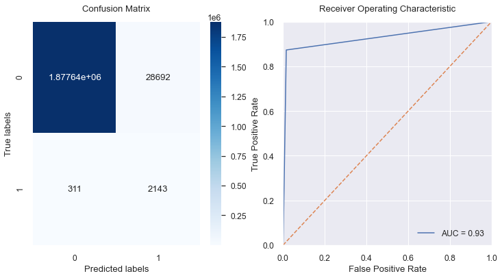

```python
# Obtener las probabilidades de la clase positiva para calcular la curva ROC
y_prob = model.predict_proba(X_test_g)[:, 1]

# Calcular la matriz de confusión
cm = confusion_matrix(Y_test_g, y_pred)

# Crear la figura y los subplots
fig, (ax1, ax2) = plt.subplots(1, 2, figsize=(12, 6))

# Crear la matriz de confusión
sns.heatmap(cm, annot=True, cmap='Blues', fmt='g', ax=ax1)

# Configurar las etiquetas de los ejes
ax1.set_xlabel('Predicted labels')
ax1.set_ylabel('True labels')
ax1.set_title('Confusion Matrix')


# Graficar la curva ROC
ax2.plot(fprRF, recallRF, label='AUC = %0.2f' % AUC_RF )
ax2.plot([0, 1], [0, 1], linestyle='--')
ax2.set_xlim([0.0, 1.0])
ax2.set_ylim([0.0, 1.0])
ax2.set_xlabel('False Positive Rate')
ax2.set_ylabel('True Positive Rate')
ax2.set_title('Receiver Operating Characteristic')
ax2.legend(loc="lower right")

# Mostrar la figura
plt.savefig('knn_Xg.tiff', dpi=300, format='tiff')
plt.show()
```

Aplicamos KNN con PCA al conjunto -h-

```python
# Crear un modelo KNN con k=3 vecinos cercanos
model = KNeighborsClassifier(n_neighbors=3)

# Entrenar el modelo utilizando el conjunto de entrenamiento
model.fit(X_t_h, Y_t_h)

# Predecir las etiquetas de clase para el conjunto de prueba
y_pred = model.predict(X_test_h)

# Evaluar la precisión del modelo
accuracy = accuracy_score(Y_test_h, y_pred)
print("Precisión:", accuracy)

# Evaluacion modelo
CM_RF = confusion_matrix(Y_test_h,y_pred)
CR_RF = classification_report(Y_test_h,y_pred)
fprRF, recallRF, thresholdsRF = roc_curve(Y_test_h, y_pred)
AUC_RF = auc(fprRF, recallRF)

resultsRF = {"Confusion Matrix":CM_RF,"Classification Report":CR_RF,"Area Under Curve":AUC_RF}

# sprint resultado

for measure in resultsRF:
    print(measure,": \n",resultsRF[measure])
```

```
Precisión: 0.9905877348220282
Confusion Matrix :
 [[1888543   17691]
 [    275    2277]]
Classification Report :
               precision    recall  f1-score   support

       False       1.00      0.99      1.00   1906234
        True       0.11      0.89      0.20      2552

    accuracy                           0.99   1908786
   macro avg       0.56      0.94      0.60   1908786
weighted avg       1.00      0.99      0.99   1908786

Area Under Curve :
 0.9414803884119882
```

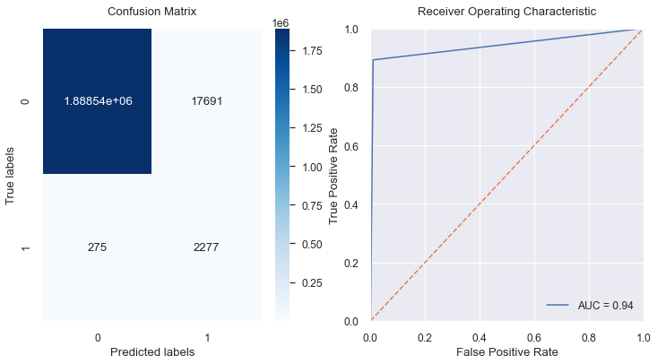

```python
# Obtener las probabilidades de la clase positiva para calcular la curva ROC
y_prob = model.predict_proba(X_test_h)[:, 1]

# Calcular la matriz de confusión
cm = confusion_matrix(Y_test_h, y_pred)

# Crear la figura y los subplots
fig, (ax1, ax2) = plt.subplots(1, 2, figsize=(12, 6))

# Crear la matriz de confusión
sns.heatmap(cm, annot=True, cmap='Blues', fmt='g', ax=ax1)

# Configurar las etiquetas de los ejes
ax1.set_xlabel('Predicted labels')
ax1.set_ylabel('True labels')
ax1.set_title('Confusion Matrix')

# Graficar la curva ROC
ax2.plot(fprRF, recallRF, label='AUC = %0.2f' % AUC_RF )
ax2.plot([0, 1], [0, 1], linestyle='--')
ax2.set_xlim([0.0, 1.0])
ax2.set_ylim([0.0, 1.0])
ax2.set_xlabel('False Positive Rate')
ax2.set_ylabel('True Positive Rate')
ax2.set_title('Receiver Operating Characteristic')
ax2.legend(loc="lower right")

# Mostrar la figura
plt.savefig('knn_Xh.tiff', dpi=300, format='tiff')
plt.show()
```